# Analysis: Report matched

## 2.5 Major subgroups within sectors

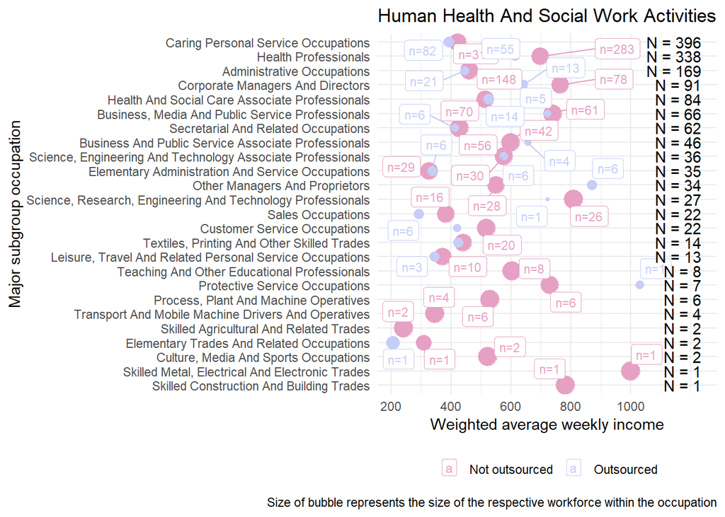

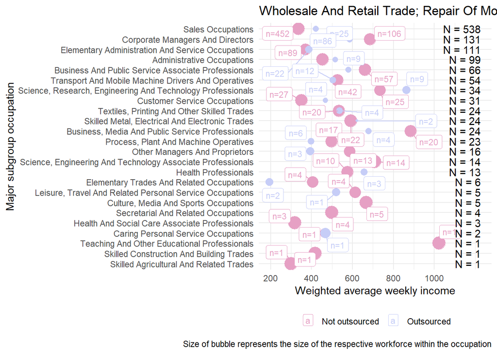

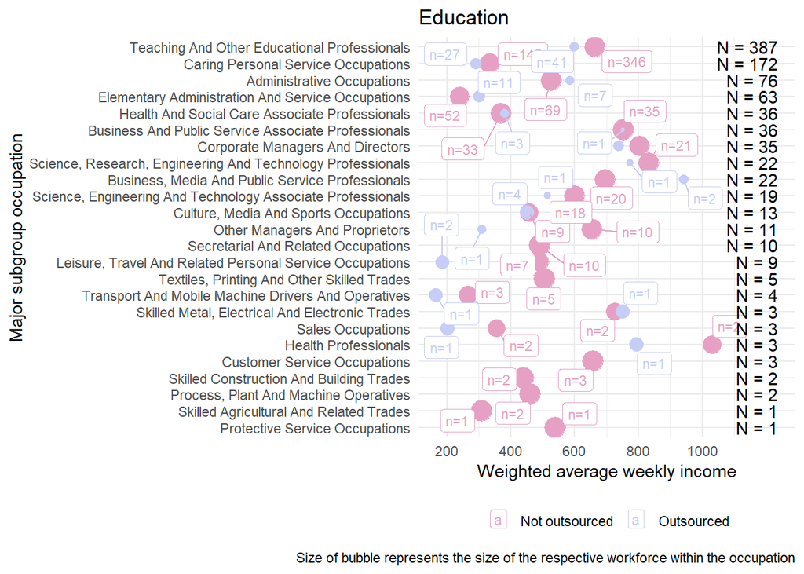

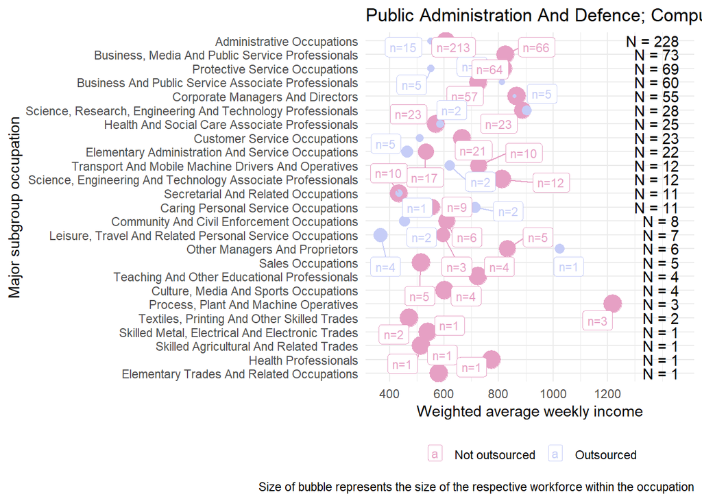

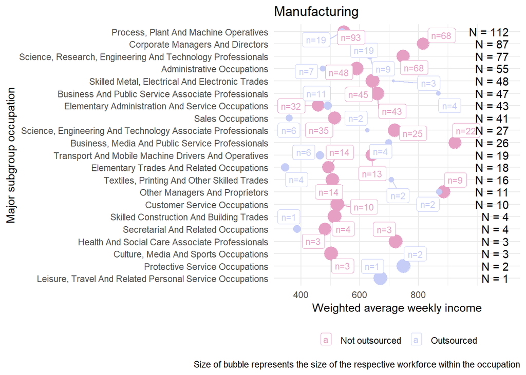

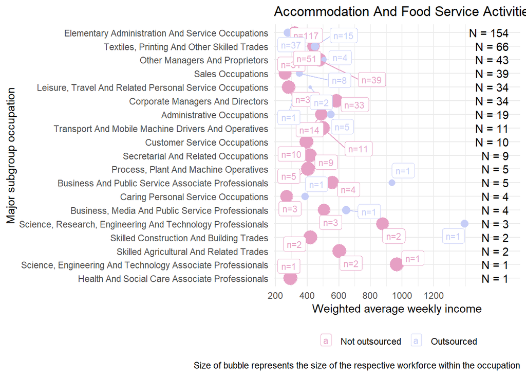

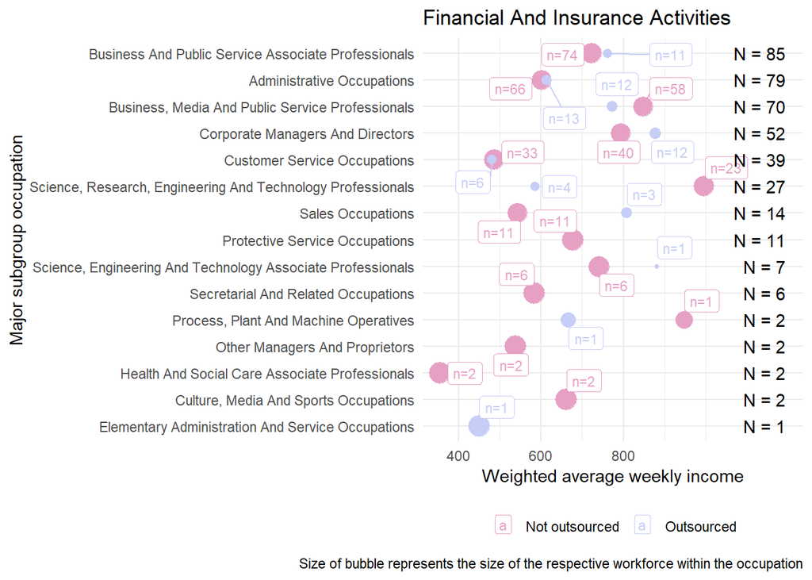

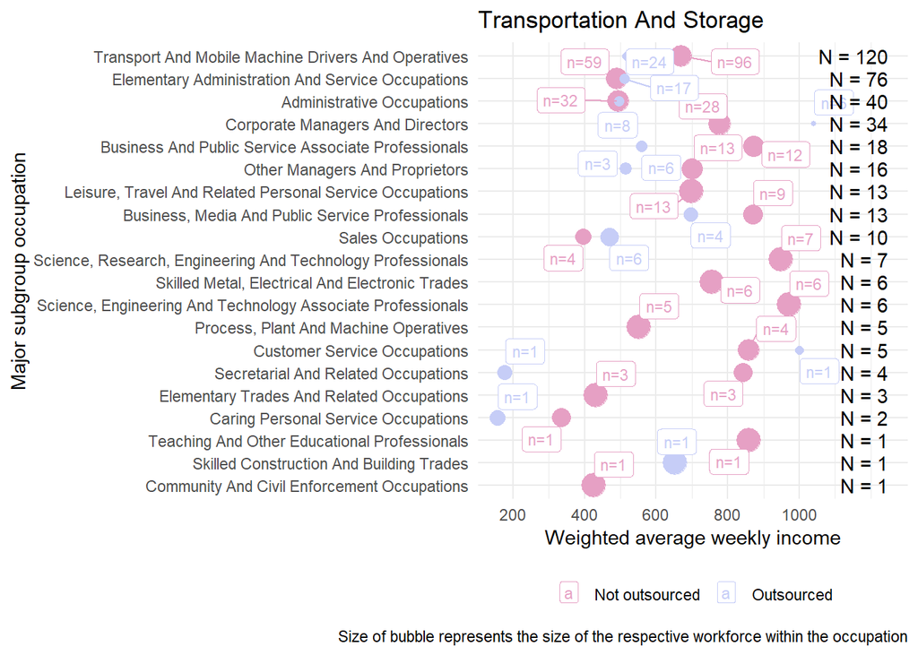

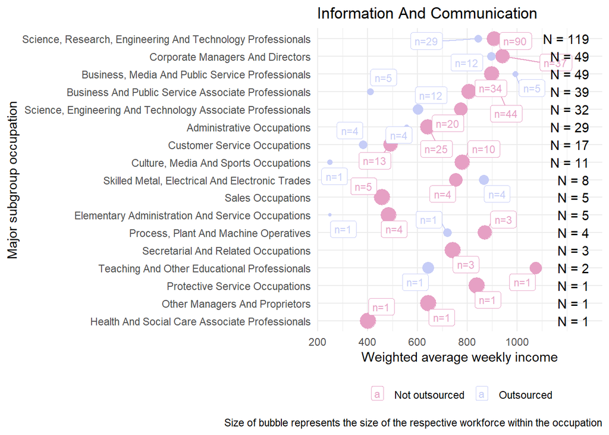

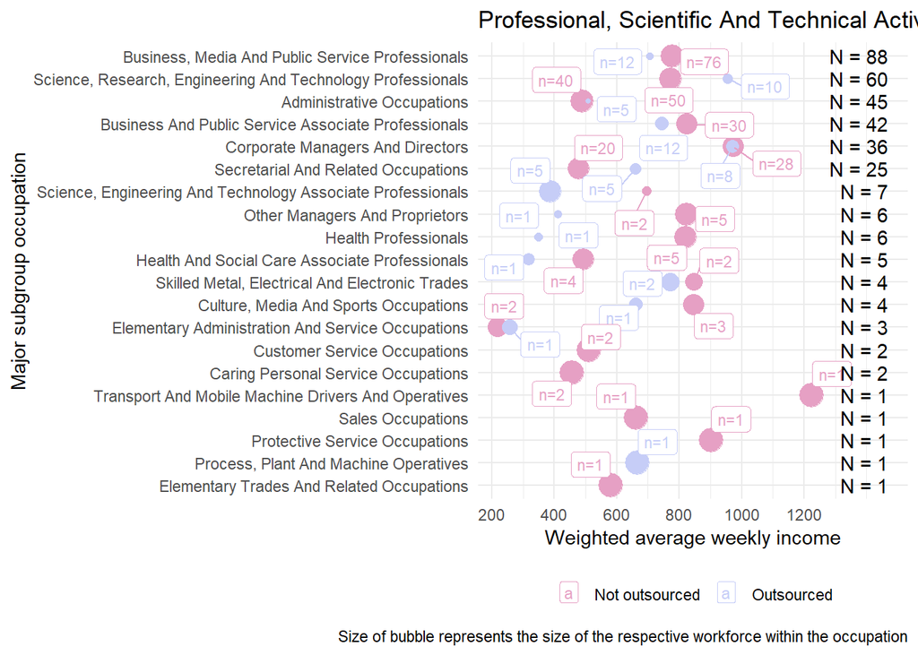

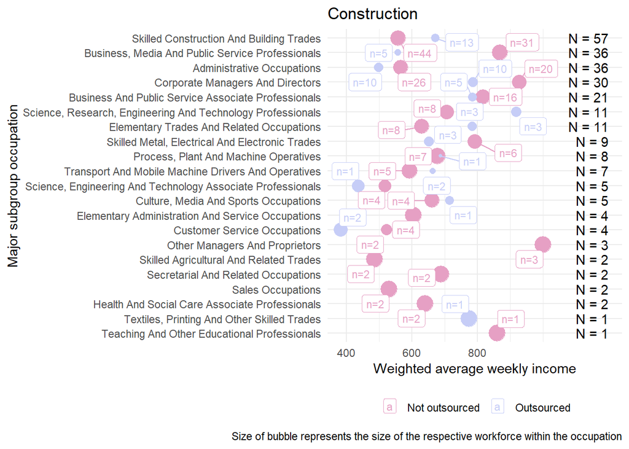

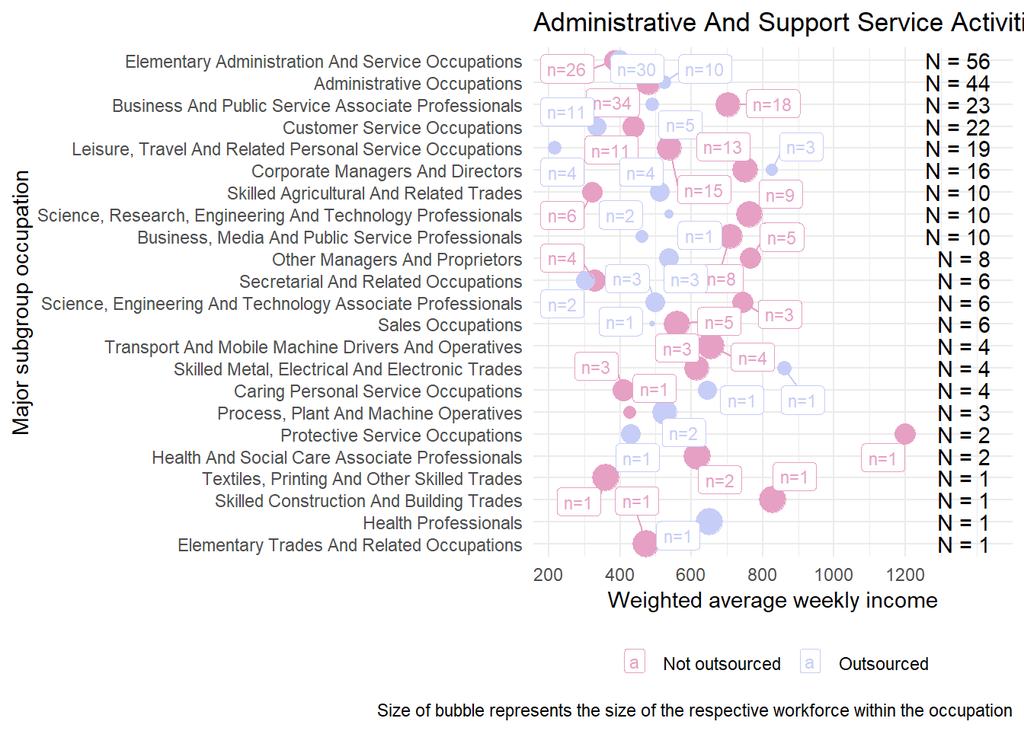

[1 more figures not shown]

```r
occ_in_sect_summary_pay <- data %>%
  filter(income_drop_all == 0 & !is.na(income_weekly_all)) %>%
  group_by(SectorName, SectorName_labelled, MajorsubgroupOccupation_labelled, outsourcing_status) %>%
  summarise(
    n = n(),
    Frequency = sum(NatRepemployees),
    avg_income = mean(income_weekly_all, na.rm=T),
    wtd_avg_income = weighted.mean(income_weekly_all, w = NatRepemployees, na.rm=T)
  ) %>%
  ungroup() %>%
  group_by(SectorName_labelled, MajorsubgroupOccupation_labelled) %>%
  mutate(
    N = sum(n),
    Sum = sum(Frequency),
    perc = 100 * (Frequency/Sum),
    MajorsubgroupOccupation_labelled = case_when(MajorsubgroupOccupation_labelled == "NA" ~ NA,
                                    TRUE ~ MajorsubgroupOccupation_labelled),
    MajorsubgroupOccupation_labelled = stringr::str_to_title(MajorsubgroupOccupation_labelled),
    SectorName_labelled = stringr::str_to_title(SectorName_labelled)

  )

summary_weekly <- occ_in_sect_summary_pay %>%
  group_by(SectorName_labelled,MajorsubgroupOccupation_labelled) %>%
  mutate(
    min_n = min(n, na.rm=TRUE)
  ) %>%
  filter(min_n >= 10) %>% # need to identify the unit occs that have an ok n
  ungroup() %>%
  mutate(
    pay_frame = "weekly"
  )

# write_csv(occ_in_sect_summary_pay, file="../outputs/data/major_subgroup_occupation_in_sector_summary_pay_weekly.csv")


for(sector in sectors_of_interest){
    #print(sector)
    # subset to this sector and drop na occupatoins
    plot_data <- occ_in_sect_summary_pay %>%
      filter(SectorName_labelled == sector) %>%
      filter(!is.na(MajorsubgroupOccupation_labelled)) %>%
      droplevels() %>%
      ungroup()

    # Order occs by N
    # First filter for 'outsourced' level and reorder by N
    not_outsourced_levels <- plot_data %>%
      dplyr::select(MajorsubgroupOccupation_labelled, outsourcing_status, N) %>%
      distinct(MajorsubgroupOccupation_labelled, N) %>%
      mutate(MajorsubgroupOccupation_labelled = forcats::fct_reorder(MajorsubgroupOccupation_labelled, N, .desc = FALSE))

    # not_outsourced_levels <- plot_data %>%
    #   filter(outsourcing_status == 'Not outsourced') %>%
    #   mutate(MajorsubgroupOccupation_labelled = forcats::fct_reorder(MajorsubgroupOccupation_labelled, N, .desc = FALSE))
    # Then apply the reordered levels back to the original data
    plot_data <- plot_data %>%
      mutate(
        MajorsubgroupOccupation_labelled = factor(MajorsubgroupOccupation_labelled, levels = levels(not_outsourced_levels$MajorsubgroupOccupation_labelled)),
            )

    annotation_df <- plot_data %>%
      #filter(outsourcing_status == "Not outsourced") %>%
      dplyr::select(MajorsubgroupOccupation_labelled, n) %>%
      group_by(MajorsubgroupOccupation_labelled) %>%
      summarise(
        N = sum(n)
      ) %>%
        mutate(
        ypos = max(plot_data$wtd_avg_income, na.rm=T) * 1.2
      )

    p <- plot_data %>%
      ggplot(., aes(wtd_avg_income, MajorsubgroupOccupation_labelled, size = perc, colour = outsourcing_status)) +
      geom_point(position = "dodge") +
    geom_label_repel(inherit.aes = F, aes(wtd_avg_income, MajorsubgroupOccupation_labelled, colour = outsourcing_status, label=paste0("n=",n)), size=3,
                    #force_pull = 2
                    ) +
      theme_minimal() +
      theme(legend.position = "bottom",
          legend.title = element_blank()) +

      #coord_flip() +
    scale_x_continuous(breaks=seq(0,max(plot_data$wtd_avg_income, na.rm=T), 200)) +
    scale_colour_manual(values=colours) +
    geom_text(inherit.aes=F,data=annotation_df, aes(x=ypos, y=MajorsubgroupOccupation_labelled, label = paste0("N = ", N)), hjust=1)  +
    guides(size=FALSE) + # remove size legend as gauging size is difficult
    xlab("Weighted average weekly income") + ylab("Major subgroup occupation") +
    labs(caption = "Size of bubble represents the size of the respective workforce within the occupation") +
      ggtitle(sector)

    show(p)

    # ggsave(here('outputs','figures','occupation_pay_plots',paste0('major_subgroup_occupation_pay_plot_weekly_', sector, '.png')), height = 8, width = 8, dpi=800, bg="white")
}
```

# 3 This group of workers is varied, spread across sectors and regions (chapter 2)

```r
sector_summary_3 <- data %>%
  #filter(income_drop_all == 0) %>%
  group_by(SectorName, SectorName_labelled, outsourcing_status) %>%
  summarise(
    n = n(),
    Frequency = sum(NatRepemployees),
    # avg_income = mean(income_annual_all, na.rm=T),
    # wtd_avg_income = weighted.mean(income_annual_all, w = NatRepemployees, na.rm=T)
  ) %>%
  ungroup() %>%
  group_by(SectorName) %>%
  mutate(
    N = sum(n),
    Sum = sum(Frequency),
    perc = 100 * (Frequency/Sum),
    SectorName_labelled = case_when(SectorName_labelled == "NA" ~ NA,
                                    TRUE ~ SectorName_labelled),
    SectorName_short = SectorName_labelled
  ) %>%
  # make the sector names more readable
  separate_wider_delim(SectorName_short, names = c("SectorName_short", "SectorName_short_detail"), delim=";",
                       too_few = "align_start") %>%
  mutate(
    SectorName_short = factor(stringr::str_to_sentence(SectorName_short)),
    SectorName_short_detail = factor(stringr::str_to_sentence(SectorName_short_detail)),
  )

# write_csv(sector_summary_3, file="../outputs/data/sector_summary_3.csv")
```

The plot below shows the proportion of outsourced and not outsourced workers within each sector. I.e. this is showing what sectors have higher and lower proportions of outsourced workers.

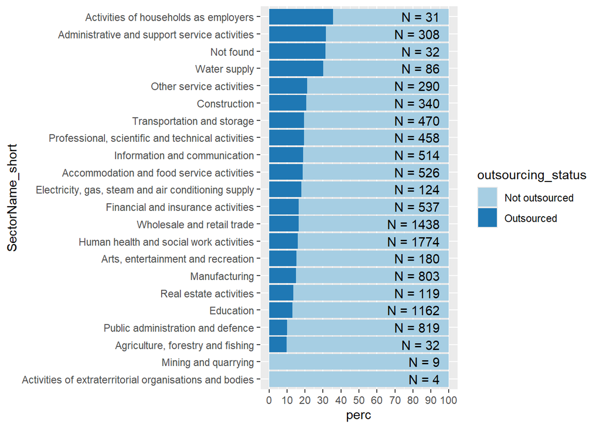

```r
plot_data <- sector_summary_3 %>%
  drop_na(SectorName_short) %>%
    droplevels() %>%
  ungroup()

# Filter for 'outsourced' level and reorder SectorName_short
not_outsourced_levels <- plot_data %>%
  filter(outsourcing_status == 'Not outsourced') %>%
  mutate(SectorName_short = forcats::fct_reorder(SectorName_short, perc, .desc = TRUE))

outsourced <- plot_data %>%
  filter(outsourcing_status == 'Outsourced') %>%
  mutate(
    rank = rank(desc(perc))
  )

# Apply the reordered levels back to the original data
plot_data <- plot_data %>%
  mutate(
    SectorName_short = factor(SectorName_short, levels = levels(not_outsourced_levels$SectorName_short)),
         )

# annotation_df <- plot_data %>%
#   dplyr::select(SectorName_short, outsourcing_status, perc, n
# mutate(

annotation_df <- plot_data %>%
  filter(outsourcing_status == "Not outsourced") %>%
  dplyr::select(SectorName_short, N) %>%
  mutate(
    ypos = 80
  )

ggplot(plot_data, aes(SectorName_short, perc, fill = outsourcing_status)) +
  geom_col() +
  geom_text(inherit.aes=F,data=annotation_df, aes(x=SectorName_short, y=ypos, label = paste0("N = ", N)), hjust=1, nudge_y = 15) +
  coord_flip() +
  scale_fill_manual(values=many_colours) +
  scale_y_continuous(breaks=seq(0,100,10))
```

```r
# sector_key <- data.frame("number" = seq(1,length(unique(plot_data$SectorName_labelled)),1),
#                           "Sector" = levels(plot_data$SectorName_labelled))
#
# sector_key %>%
#   kable() %>%
#   kable_styling(full_width = F)
```

The top three Sectors with the highest proportion of outsourced workers are:

- ACTIVITIES OF HOUSEHOLDS AS EMPLOYERS; UNDIFFERENTIATED GOODS-AND SERVICES-PRODUCING ACTIVITIES OF HOUSEHOLDS FOR OWN US (note that N = 31)
- ADMINISTRATIVE AND SUPPORT SERVICE ACTIVITIES
- WATER SUPPLY; SEWERAGE, WASTE MANAGEMENT AND REMEDIATION ACTIVITIES

Note that for an undefined sector (‘Not found’) contained one of the largest proportions of outsourced workers (31% of workers in the ‘Not found’ category were outsourced).

A key takeaway here is that whereas the total outsourced population is 17%, this figure varies by sector, from 0% for Mining… and Extraterritoral organisations… all the way to 36% for Activities of households as employers, with 5 out 20 sectors having at least 20% of their workforce outsourced.

The plot below shows the proportion of workers within each region who are outsourced.

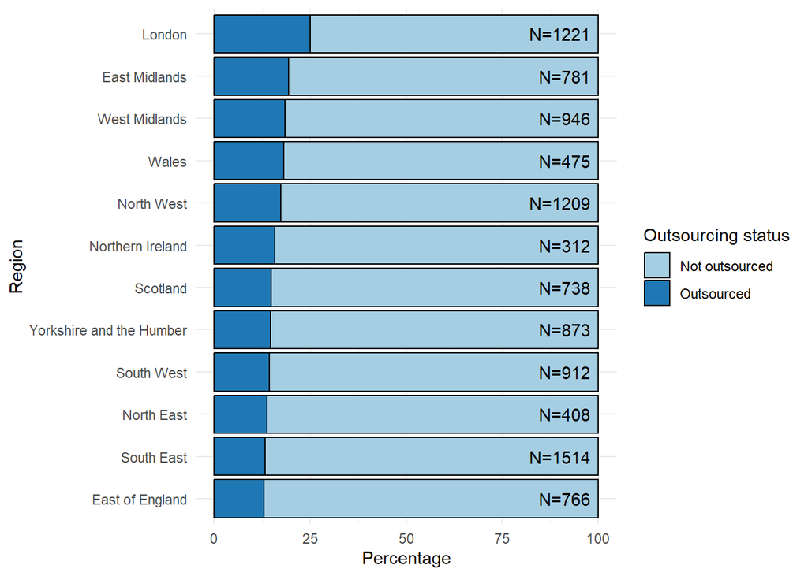

```r
region_statistics_2 <- data %>%
  # get values of labels
  # mutate_all(haven::as_factor) %>%
  group_by(Region, outsourcing_status) %>%
  summarise(
    Frequency = sum(NatRepemployees),
    n = n(),
  ) %>%
  mutate(
    N = sum(n),
    Sum = sum(Frequency),
    Percentage = 100 * (Frequency / Sum)
  ) %>%
  rename(
    `Outsourcing status` = outsourcing_status
  ) %>%
  ungroup()

reg_levels <- region_statistics_2 %>%
  filter(`Outsourcing status` == "Outsourced") %>%
  mutate(
    Region = forcats::fct_reorder(Region, Percentage, .desc=FALSE)
  )

annotation_df <- region_statistics_2 %>%
  filter(`Outsourcing status` == "Not outsourced") %>%
  dplyr::select(Region, N) %>%
  mutate(
    ypos = 100
  )

region_statistics_2 %>%
  mutate(
    Region = factor(Region, levels = levels(reg_levels$Region))
  ) %>%
  ggplot(., aes(Region, Percentage, fill = `Outsourcing status`)) +
  geom_col(colour="black") +
  geom_text(inherit.aes=F, data = annotation_df, aes(Region, ypos, label = paste0("N=",N)), hjust=1, nudge_y = -2) +
  coord_flip() +
  scale_fill_manual(values=many_colours) +
  theme_minimal()
```

```r
# readr::write_csv(region_statistics_2, file = "../outputs/data/region_stats_2.csv")

region_statistics_2_1 <- region_statistics_2 %>%
  filter(`Outsourcing status` == "Outsourced" & Region != "London")

london_perc <- region_statistics_2[which(region_statistics_2$Region == "London" & region_statistics_2["Outsourcing status"] == "Outsourced"), "Percentage"]
```

```r
region_statistics_3 <- data %>%
  filter(outsourcing_status == "Outsourced") %>%
  # get values of labels
  # mutate_all(haven::as_factor) %>%
  group_by(Region) %>%
  summarise(
    Frequency = sum(NatRepemployees)
  ) %>%
  mutate(
    Sum = sum(Frequency),
    Percentage = 100 * (Frequency / Sum)
  )

# readr::write_csv(region_statistics_3, file = "../outputs/data/region_stats_3.csv")
```

```r
region_statistics_3 %>%
  mutate(
    Region = haven::as_factor(Region)
    ) %>%
  arrange(desc(Percentage)) %>%
  knitr::kable(.,digits = 2) %>%
  kable_styling(full_width = F)
```

Table 3: Distribution of outsourced workers across regions

| Region | Frequency | Sum | Percentage |
| --- | --- | --- | --- |
| London | 357.35 | 1708.36 | 20.92 |
| North West | 189.39 | 1708.36 | 11.09 |
| South East | 188.47 | 1708.36 | 11.03 |
| West Midlands | 161.49 | 1708.36 | 9.45 |
| East Midlands | 140.50 | 1708.36 | 8.22 |
| Scotland | 125.82 | 1708.36 | 7.37 |
| East of England | 125.49 | 1708.36 | 7.35 |
| South West | 120.50 | 1708.36 | 7.05 |
| Yorkshire and the Humber | 119.46 | 1708.36 | 6.99 |
| Wales | 83.25 | 1708.36 | 4.87 |
| North East | 53.06 | 1708.36 | 3.11 |
| Northern Ireland | 43.56 | 1708.36 | 2.55 |

# 4 Our data indicates a racialised picture of outsourcing in the UK

All models were run with a quasibinomial distribution to account for the survey weights. Because quasibinomial models don’t involve likelihoods, model fit could not be determined using information criteria. Instead, we use Tjur’s pseudo *R<sup>2</sup>* to appraise model fit. This approach uses predicted probabilities from the model to calculate the average predicted probability for each level of the outcome variable, then takes the difference in this average between the two levels. The result is a figure between 0 and 1 that estimates how different the average predicted probability in the outsourced group is from the average predicted probability in the not outsourced group. Values closer to 1 indicate the averages are more different and therefore that the model is more accurate in discriminating between the two groups.

```r
mod2 <- glm(outsourcing_status ~ Ethnicity_binary + Age + Gender + Has_Degree +  Region + BORNUK_labelled, data, weights = NatRepemployees, family="quasibinomial")
test <- data['NatRepemployees']

model_data <- mod2[["model"]] |>
  rename(
    NatRepemployees = `(weights)`
  )

tjur2 <- model_data %>%
  mutate(pred = predict(mod2, type = "response")) %>%
  group_by(outsourcing_status) %>%
  summarise(weighted_mean = weighted.mean(pred, NatRepemployees)) %>%
  summarise(tjur_r2 = diff(weighted_mean)) %>%
  pull()

coefs <- extract_glm_coefs(mod2, only_sig=F)
ethn_coef <- coefs %>% filter(stringr::str_detect(variable, "Ethnicity"))
```

## 4.1 svy

```r
library(survey)

# Step 1: Create a survey design object
design <- svydesign(
  ids = ~1,                                # Assuming no clustering
  weights = ~NatRepemployees,             # Your national survey weights
  data = data
)

# Step 2: Fit the model with quasibinomial family
mod_svy1 <- svyglm(
  outsourcing_status ~ Ethnicity_binary,
  design = design,
  family = quasibinomial()
)

# Step 2: Fit the model with quasibinomial family
mod_svy2 <- svyglm(
  outsourcing_status ~ Ethnicity_binary + Age + Gender + Has_Degree +  Region + BORNUK_labelled,
  design = design,
  family = quasibinomial()
)

# Step 3: View results
summary(mod_svy1)
```

```
Call:
svyglm(formula = outsourcing_status ~ Ethnicity_binary, design = design,
    family = quasibinomial())

Survey design:
svydesign(ids = ~1, weights = ~NatRepemployees, data = data)

Coefficients:
                                                      Estimate Std. Error
(Intercept)                                           -1.72982    0.03561
Ethnicity_binaryNon-White                              0.70489    0.07895
Ethnicity_binaryDon't think of myself as any of these  1.03914    0.62993
Ethnicity_binaryPrefer not to say                      0.50493    0.60277
                                                      t value
(Intercept)                                           -48.576
Ethnicity_binaryNon-White                               8.929
Ethnicity_binaryDon't think of myself as any of these   1.650
Ethnicity_binaryPrefer not to say                       0.838
                                                                 Pr(>|t|)
(Intercept)                                           <0.0000000000000002 ***
Ethnicity_binaryNon-White                             <0.0000000000000002 ***
Ethnicity_binaryDon't think of myself as any of these              0.0991 .
Ethnicity_binaryPrefer not to say                                  0.4022
---
Signif. codes:  0 '***' 0.001 '**' 0.01 '*' 0.05 '.' 0.1 ' ' 1

(Dispersion parameter for quasibinomial family taken to be 1.000254)

Number of Fisher Scoring iterations: 4
```

```r
summary(mod_svy2)
```

```
Call:
svyglm(formula = outsourcing_status ~ Ethnicity_binary + Age +
    Gender + Has_Degree + Region + BORNUK_labelled, design = design,
    family = quasibinomial())

Survey design:
svydesign(ids = ~1, weights = ~NatRepemployees, data = data)

Coefficients:
                                                       Estimate Std. Error
(Intercept)                                           -0.431189   0.141422
Ethnicity_binaryNon-White                              0.323011   0.095015
Ethnicity_binaryDon't think of myself as any of these  0.915273   0.605559
Ethnicity_binaryPrefer not to say                      0.345619   0.658664
Age                                                   -0.021759   0.002671
GenderFemale                                          -0.370687   0.065623
GenderOther                                           -0.141918   0.710993
GenderPrefer not to say                               -0.203829   0.576995
Has_DegreeNo                                           0.058631   0.065681
Has_DegreeDon't know                                   0.133973   0.295197
RegionEast Midlands                                   -0.059498   0.142534
RegionEast of England                                 -0.527224   0.151800
RegionNorth East                                      -0.455546   0.181779
RegionNorth West                                      -0.168194   0.126848
RegionNorthern Ireland                                -0.357633   0.216009
RegionScotland                                        -0.379294   0.155729
RegionSouth East                                      -0.472453   0.120562
RegionSouth West                                      -0.386809   0.140987
RegionWales                                           -0.095940   0.161062
RegionWest Midlands                                   -0.180531   0.130428
RegionYorkshire and the Humber                        -0.384326   0.137729
BORNUK_labelledWithin the last year                    0.525123   0.203462
BORNUK_labelledWithin the last 3 years                 0.030434   0.211028
BORNUK_labelledWithin the last 5 years                 0.195695   0.225725
BORNUK_labelledWithin the last 10 years                0.475519   0.173703
BORNUK_labelledWithin the last 15 years                0.457049   0.205897
BORNUK_labelledWithin the last 20 years                0.430150   0.217431
BORNUK_labelledWithin the last 30 years               -0.799520   0.367122
BORNUK_labelledMore than 30 years ago                  0.699059   0.217928
BORNUK_labelledPrefer not to say                       0.198606   0.276293
```

[output cut: 53 more lines]

```
BORNUK_labelledWithin the last year                              0.009868 **
BORNUK_labelledWithin the last 3 years                           0.885332
BORNUK_labelledWithin the last 5 years                           0.385983
BORNUK_labelledWithin the last 10 years                          0.006201 **
BORNUK_labelledWithin the last 15 years                          0.026455 *
BORNUK_labelledWithin the last 20 years                          0.047920 *
BORNUK_labelledWithin the last 30 years                          0.029444 *
BORNUK_labelledMore than 30 years ago                            0.001342 **
BORNUK_labelledPrefer not to say                                 0.472266
---
Signif. codes:  0 '***' 0.001 '**' 0.01 '*' 0.05 '.' 0.1 ' ' 1

(Dispersion parameter for quasibinomial family taken to be 0.9971119)

Number of Fisher Scoring iterations: 4
```

```r
anova(mod_svy1,mod_svy2)
```

```
Working (Rao-Scott+F) LRT for Age Gender Has_Degree Region BORNUK_labelled
 in svyglm(formula = outsourcing_status ~ Ethnicity_binary + Age +
    Gender + Has_Degree + Region + BORNUK_labelled, design = design,
    family = quasibinomial())
Working 2logLR =  189.6788 p= < 0.000000000000000222
(scale factors:  1.5 1.3 1.2 1.2 1.2 1.2 1.1 1.1 1.1 1 0.98 0.97 0.96 0.95 0.95 0.92 0.91 0.89 0.87 0.84 0.83 0.83 0.81 0.8 0.78 0.74 );  denominator df= 9782
```

```r
anova(mod_svy1,mod_svy2, method="Wald")
```

```
Wald test for Age Gender Has_Degree Region BORNUK_labelled
 in svyglm(formula = outsourcing_status ~ Ethnicity_binary + Age +
    Gender + Has_Degree + Region + BORNUK_labelled, design = design,
    family = quasibinomial())
F =  6.928185  on  26  and  9782  df: p= < 0.000000000000000222
```

```r
coefs2 <- extract_glm_coefs(mod_svy2, only_sig=F)
```

```r
regTermTest(mod_svy2, ~ Age + Gender + Has_Degree + Region + BORNUK_labelled)
```

```
Wald test for Age Gender Has_Degree Region BORNUK_labelled
 in svyglm(formula = outsourcing_status ~ Ethnicity_binary + Age +
    Gender + Has_Degree + Region + BORNUK_labelled, design = design,
    family = quasibinomial())
F =  6.928185  on  26  and  9782  df: p= < 0.000000000000000222
```

```r
regTermTest(mod_svy2, ~ Age + Gender + Has_Degree + Region + BORNUK_labelled, method = "Wald")
```

```
Wald test for Age Gender Has_Degree Region BORNUK_labelled
 in svyglm(formula = outsourcing_status ~ Ethnicity_binary + Age +
    Gender + Has_Degree + Region + BORNUK_labelled, design = design,
    family = quasibinomial())
F =  6.928185  on  26  and  9782  df: p= < 0.000000000000000222
```

For model 1, the value of Tjur’s pseudo *R<sup>2</sup>* is 0.038. The table below shows the model coefficients.

```r
labels <- c(
  'Intercept',
  'Ethnicity: Not White',
  'Age',
  'Gender: Male',
  'Gender: Other',
  'Gender: Prefer not to say',
  'Education: Has degree',
  "Education: Don't know",
  'Region: East Midlands',
  'Region: East of England',
  'Region: North East',
  'Region: North West',
  'Region: Northern Ireland',
  'Region: Scotland',
  'Region: South East',
  'Region: South West',
  'Region: Wales',
  'Region: West Midlands',
  'Region: Yorkshire and the Humber',
  'Migration: Arrived within the last year',
  'Migration: Arrived within the last 3 years',
  'Migration: Arrived within the last 5 years',
  'Migration: Arrived within the last 10 years',
  'Migration: Arrived within the last 15 years',
  'Migration: Arrived within the last 20 years',
  'Migration: Arrived within the last 30 years',
  'Migration: Arrived more than 30 years ago',
  'Migration: Prefer not to say'
)


tab_model(mod2,
          pred.labels = labels,
          dv.labels = "Outsourcing",
          show.r2 = FALSE)
```

|  | Outsourcing |  |  |
| --- | --- | --- | --- |
| Predictors | Odds Ratios | CI | p |
| (Intercept) | 0.65 | 0.51 – 0.82 | **<0.001** |
| Ethnicity_binaryNon-White | 1.38 | 1.18 – 1.62 | **<0.001** |
| Ethnicity_binaryDon't think of myself as any of these | 2.50 | 0.49 – 10.34 | 0.222 |
| Ethnicity_binaryPrefer not to say | 1.41 | 0.54 – 3.25 | 0.443 |
| Age | 0.98 | 0.97 – 0.98 | **<0.001** |
| GenderFemale | 0.69 | 0.62 – 0.77 | **<0.001** |
| GenderOther | 0.87 | 0.17 – 2.92 | 0.837 |
| GenderPrefer not to say | 0.82 | 0.24 – 2.11 | 0.705 |
| Has_DegreeNo | 1.06 | 0.95 – 1.19 | 0.312 |
| Has_DegreeDon't know | 1.14 | 0.74 – 1.73 | 0.538 |
| RegionEast Midlands | 0.94 | 0.75 – 1.19 | 0.614 |
| RegionEast of England | 0.59 | 0.46 – 0.75 | **<0.001** |
| RegionNorth East | 0.63 | 0.45 – 0.87 | **0.006** |
| RegionNorth West | 0.85 | 0.68 – 1.04 | 0.122 |
| RegionNorthern Ireland | 0.70 | 0.47 – 1.01 | 0.062 |
| RegionScotland | 0.68 | 0.54 – 0.87 | **0.002** |
| RegionSouth East | 0.62 | 0.51 – 0.77 | **<0.001** |
| RegionSouth West | 0.68 | 0.53 – 0.86 | **0.002** |
| RegionWales | 0.91 | 0.68 – 1.20 | 0.503 |
| RegionWest Midlands | 0.83 | 0.67 – 1.04 | 0.110 |
| RegionYorkshire and the Humber | 0.68 | 0.53 – 0.86 | **0.002** |
| BORNUK_labelledWithin the last year | 1.69 | 1.16 – 2.44 | **0.006** |
| BORNUK_labelledWithin the last 3 years | 1.03 | 0.70 – 1.50 | 0.876 |
| BORNUK_labelledWithin the last 5 years | 1.22 | 0.81 – 1.78 | 0.325 |
| BORNUK_labelledWithin the last 10 years | 1.61 | 1.20 – 2.13 | **0.001** |
| BORNUK_labelledWithin the last 15 years | 1.58 | 1.13 – 2.17 | **0.006** |
| BORNUK_labelledWithin the last 20 years | 1.54 | 1.06 – 2.19 | **0.019** |
| BORNUK_labelledWithin the last 30 years | 0.45 | 0.22 – 0.81 | **0.014** |
| BORNUK_labelledMore than 30 years ago | 2.01 | 1.41 – 2.82 | **<0.001** |
| BORNUK_labelledPrefer not to say | 1.22 | 0.73 – 1.96 | 0.429 |
| Observations | 9812 |  |  |

```r
mod <- glm(outsourcing_status ~ Ethnicity_collapsed + Age + Gender + Has_Degree + Region + BORNUK_labelled, data, weights = NatRepemployees, family="quasibinomial")

model_data <- mod2[["model"]] |>
  rename(
    NatRepemployees = `(weights)`
  )

tjur <- model_data %>%
  mutate(pred = predict(mod, type = "response")) %>%
  group_by(outsourcing_status) %>%
  summarise(weighted_mean = weighted.mean(pred, NatRepemployees)) %>%
  summarise(tjur_r2 = diff(weighted_mean)) %>%
  pull()

coefs <- extract_glm_coefs(mod, only_sig=T)

ethn_coef <- coefs %>% filter(stringr::str_detect(variable, "Ethnicity"))
```

## 4.2 svy

```r
# Now, fit the model again
design <- svydesign(
  ids = ~1,  # Assuming no clustering
  weights = ~NatRepemployees,  # Survey weights
  data = data
)

mod_svy <- svyglm(
  outsourcing_status ~ Ethnicity_collapsed + Age + Gender + Has_Degree + Region + BORNUK_labelled,
  design = design,
  family = quasibinomial()
)

# Check results
summary(mod_svy)
```

```
Call:
svyglm(formula = outsourcing_status ~ Ethnicity_collapsed + Age +
    Gender + Has_Degree + Region + BORNUK_labelled, design = design,
    family = quasibinomial())

Survey design:
svydesign(ids = ~1, weights = ~NatRepemployees, data = data)

Coefficients:
                                                          Estimate Std. Error
(Intercept)                                              -0.406470   0.142059
Ethnicity_collapsedArab/British Arab                      0.682220   0.484486
Ethnicity_collapsedAsian/Asian British                    0.214008   0.127802
Ethnicity_collapsedBlack/African/Caribbean/Black British  0.381906   0.147709
Ethnicity_collapsedDon't think of myself as any of these  0.855285   0.607091
Ethnicity_collapsedMixed/Multiple ethnic group            0.316940   0.163581
Ethnicity_collapsedOther ethnic group                     0.031996   0.691992
Ethnicity_collapsedPrefer not to say                      0.311365   0.663666
Ethnicity_collapsedWhite other                           -0.216133   0.165154
Age                                                      -0.021806   0.002663
GenderFemale                                             -0.371394   0.065675
GenderOther                                              -0.127294   0.721195
GenderPrefer not to say                                  -0.213817   0.577398
Has_DegreeNo                                              0.060599   0.065759
Has_DegreeDon't know                                      0.146571   0.293783
RegionEast Midlands                                      -0.069134   0.142820
RegionEast of England                                    -0.546648   0.151942
RegionNorth East                                         -0.477905   0.182340
RegionNorth West                                         -0.187419   0.128086
RegionNorthern Ireland                                   -0.329967   0.217529
RegionScotland                                           -0.396867   0.156143
RegionSouth East                                         -0.492673   0.121412
RegionSouth West                                         -0.405145   0.142273
RegionWales                                              -0.115382   0.161714
RegionWest Midlands                                      -0.190143   0.131037
RegionYorkshire and the Humber                           -0.404261   0.138642
BORNUK_labelledWithin the last year                       0.539025   0.212136
BORNUK_labelledWithin the last 3 years                    0.079106   0.215271
BORNUK_labelledWithin the last 5 years                    0.268648   0.233198
BORNUK_labelledWithin the last 10 years                   0.588900   0.193470
```

[output cut: 68 more lines]

```
BORNUK_labelledWithin the last year                                0.011071 *
BORNUK_labelledWithin the last 3 years                             0.713275
BORNUK_labelledWithin the last 5 years                             0.249342
BORNUK_labelledWithin the last 10 years                            0.002342 **
BORNUK_labelledWithin the last 15 years                            0.012659 *
BORNUK_labelledWithin the last 20 years                            0.023879 *
BORNUK_labelledWithin the last 30 years                            0.055517 .
BORNUK_labelledMore than 30 years ago                              0.000797 ***
BORNUK_labelledPrefer not to say                                   0.429949
---
Signif. codes:  0 '***' 0.001 '**' 0.01 '*' 0.05 '.' 0.1 ' ' 1

(Dispersion parameter for quasibinomial family taken to be 0.9966506)

Number of Fisher Scoring iterations: 4
```

```r
model_data <- mod2[["model"]] |>
  rename(
    NatRepemployees = `(weights)`
  )


tjur <- model_data %>%
  mutate(pred = predict(mod_svy, type = "response")) %>%
  group_by(outsourcing_status) %>%
  summarise(weighted_mean = weighted.mean(pred, NatRepemployees)) %>%
  summarise(tjur_r2 = diff(weighted_mean)) %>%
  pull()
```

For model 2, the value of Tjur’s pseudo *R<sup>2</sup>* for this model is 0.039. The table below shows the model coefficients.

```r
labels <- c(
  'Intercept',
  'Ethnicity: Arab/British Arab',
  'Ethnicity: Asian/Asian British',
  'Ethnicity: Black/African/Caribbean/Black British',
  'Ethnicity: Mixed/Multiple ethnic group',
  'Ethnicity: Other ethnic group',
  'Ethnicity: Prefer not to say',
  'Ethnicity: White other',
  'Age',
  'Gender: Male',
  'Gender: Other',
  'Gender: Prefer not to say',
  'Education: Has degree',
  "Education: Don't know",
  'Region: East Midlands',
  'Region: East of England',
  'Region: North East',
  'Region: North West',
  'Region: Northern Ireland',
  'Region: Scotland',
  'Region: South East',
  'Region: South West',
  'Region: Wales',
  'Region: West Midlands',
  'Region: Yorkshire and the Humber',
  'Migration: Arrived within the last year',
  'Migration: Arrived within the last 3 years',
  'Migration: Arrived within the last 5 years',
  'Migration: Arrived within the last 10 years',
  'Migration: Arrived within the last 15 years',
  'Migration: Arrived within the last 20 years',
  'Migration: Arrived within the last 30 years',
  'Migration: Arrived more than 30 years ago',
  'Migration: Prefer not to say'
)

tab_model(mod,
          pred.labels = labels,
          dv.labels = "Outsourcing",
          show.r2 = FALSE)
```

|  | Outsourcing |  |  |
| --- | --- | --- | --- |
| Predictors | Odds Ratios | CI | p |
| (Intercept) | 0.67 | 0.52 – 0.85 | **0.001** |
| Ethnicity_collapsedArab/British Arab | 1.98 | 0.92 – 4.10 | 0.072 |
| Ethnicity_collapsedAsian/Asian British | 1.24 | 1.01 – 1.51 | **0.037** |
| Ethnicity_collapsedBlack/African/Caribbean/Black British | 1.47 | 1.10 – 1.94 | **0.008** |
| Ethnicity_collapsedDon't think of myself as any of these | 2.35 | 0.46 – 9.78 | 0.255 |
| Ethnicity_collapsedMixed/Multiple ethnic group | 1.37 | 0.95 – 1.94 | 0.080 |
| Ethnicity_collapsedOther ethnic group | 1.03 | 0.40 – 2.33 | 0.942 |
| Ethnicity_collapsedPrefer not to say | 1.37 | 0.52 – 3.15 | 0.491 |
| Ethnicity_collapsedWhite other | 0.81 | 0.61 – 1.05 | 0.117 |
| Age | 0.98 | 0.97 – 0.98 | **<0.001** |
| GenderFemale | 0.69 | 0.62 – 0.77 | **<0.001** |
| GenderOther | 0.88 | 0.18 – 2.96 | 0.853 |
| GenderPrefer not to say | 0.81 | 0.24 – 2.09 | 0.691 |
| Has_DegreeNo | 1.06 | 0.95 – 1.19 | 0.297 |
| Has_DegreeDon't know | 1.16 | 0.74 – 1.75 | 0.501 |
| RegionEast Midlands | 0.93 | 0.74 – 1.18 | 0.559 |
| RegionEast of England | 0.58 | 0.45 – 0.73 | **<0.001** |
| RegionNorth East | 0.62 | 0.44 – 0.85 | **0.004** |
| RegionNorth West | 0.83 | 0.67 – 1.03 | 0.086 |
| RegionNorthern Ireland | 0.72 | 0.49 – 1.04 | 0.087 |
| RegionScotland | 0.67 | 0.53 – 0.85 | **0.001** |
| RegionSouth East | 0.61 | 0.50 – 0.75 | **<0.001** |
| RegionSouth West | 0.67 | 0.52 – 0.85 | **0.001** |
| RegionWales | 0.89 | 0.67 – 1.18 | 0.422 |
| RegionWest Midlands | 0.83 | 0.66 – 1.03 | 0.093 |
| RegionYorkshire and the Humber | 0.67 | 0.52 – 0.85 | **0.001** |
| BORNUK_labelledWithin the last year | 1.71 | 1.16 – 2.51 | **0.006** |
| BORNUK_labelledWithin the last 3 years | 1.08 | 0.73 – 1.58 | 0.690 |
| BORNUK_labelledWithin the last 5 years | 1.31 | 0.86 – 1.94 | 0.193 |
| BORNUK_labelledWithin the last 10 years | 1.80 | 1.31 – 2.47 | **<0.001** |
| BORNUK_labelledWithin the last 15 years | 1.74 | 1.22 – 2.46 | **0.002** |
| BORNUK_labelledWithin the last 20 years | 1.68 | 1.14 – 2.43 | **0.007** |
| BORNUK_labelledWithin the last 30 years | 0.49 | 0.24 – 0.89 | **0.030** |
| BORNUK_labelledMore than 30 years ago | 2.09 | 1.46 – 2.94 | **<0.001** |
| BORNUK_labelledPrefer not to say | 1.24 | 0.74 – 2.01 | 0.387 |
| Observations | 9812 |  |  |

```r
mod <- glm(outsourcing_status ~ Ethnicity_collapsed_disaggregated + Age + Gender + Has_Degree + Region + BORNUK_labelled, data, weights = NatRepemployees, family="quasibinomial")
summary(mod)

# Test waht amount of variacne the unweighted would explain - similar
# test <- glm(outsourcing_status ~ Ethnicity_collapsed_disaggregated + Age + Gender + Has_Degree + Region + BORNUK_labelled, data, family="binomial")
# with(summary(test), 1 - deviance/null.deviance)


tjur <- data %>%
  filter(!is.na(Ethnicity_collapsed_disaggregated)) %>%
  mutate(pred = predict(mod, type = "response")) %>%
  group_by(outsourcing_status) %>%
  summarise(weighted_mean = weighted.mean(pred, NatRepemployees)) %>%
  summarise(tjur_r2 = diff(weighted_mean)) %>%
  pull()

coefs <- extract_glm_coefs(mod, only_sig=T)

ethn_coef <- coefs %>% filter(stringr::str_detect(variable, "Ethnicity"))
```

For model 3, the value of Tjur’s pseudo *R<sup>2</sup>* for this model is 0.043. The table below shows the model coefficients.

```r
labels <- c(
  'Intercept',
  "Ethnicity: Irish",
  "Ethnicity: Gypsy or Irish Traveller",
  "Ethnicity: Roma",
  "Ethnicity: Any other White background",
  "Ethnicity: White and Black Caribbean",
  "Ethnicity: White and Black African",
  "Ethnicity: White and Asian",
  "Ethnicity: Any other Mixed/Multiple ethnic background",
  "Ethnicity: Indian",
  "Ethnicity: Pakistani",
  "Ethnicity: Bangladeshi",
  "Ethnicity: Chinese",
  "Ethnicity: Any other Asian background",
  "Ethnicity: African",
  "Ethnicity: Caribbean",
  "Ethnicity: Any other Black, Black British, or Caribbean background",
  "Ethnicity: Arab",
  "Ethnicity: Any other ethnic group",
  "Ethnicity: Don't think of myself as any of these",
  "Ethnicity: Prefer not to say",
  'Age',
  'Gender: Male',
  'Gender: Other',
  'Gender: Prefer not to say',
  'Education: Has degree',
  "Education: Don't know",
  'Region: East Midlands',
  'Region: East of England',
  'Region: North East',
  'Region: North West',
  'Region: Northern Ireland',
  'Region: Scotland',
  'Region: South East',
  'Region: South West',
  'Region: Wales',
  'Region: West Midlands',
  'Region: Yorkshire and the Humber',
  'Migration: Arrived within the last year',
  'Migration: Arrived within the last 3 years',
  'Migration: Arrived within the last 5 years',
  'Migration: Arrived within the last 10 years',
  'Migration: Arrived within the last 15 years',
  'Migration: Arrived within the last 20 years',
  'Migration: Arrived within the last 30 years',
  'Migration: Arrived more than 30 years ago',
  'Migration: Prefer not to say'
)

tab_model(mod,
          pred.labels = labels,
          dv.labels = "Outsourcing",
          show.r2 = FALSE)
```

|  | Outsourcing |  |  |
| --- | --- | --- | --- |
| Predictors | Odds Ratios | CI | p |
| Intercept | 0.67 | 0.52 – 0.85 | **0.001** |
| Ethnicity: Irish | 0.76 | 0.41 – 1.33 | 0.362 |
| Ethnicity: Gypsy or Irish Traveller | 1.00 | 0.18 – 3.75 | 0.998 |
| Ethnicity: Roma | 1.25 | 0.20 – 5.71 | 0.788 |
| Ethnicity: Any other White background | 0.80 | 0.59 – 1.08 | 0.145 |
| Ethnicity: White and Black Caribbean | 0.49 | 0.18 – 1.09 | 0.112 |
| Ethnicity: White and Black African | 2.66 | 1.30 – 5.30 | **0.006** |
| Ethnicity: White and Asian | 1.19 | 0.53 – 2.43 | 0.647 |
| Ethnicity: Any other Mixed/Multiple ethnic background | 2.00 | 1.04 – 3.68 | **0.031** |
| Ethnicity: Indian | 1.18 | 0.87 – 1.57 | 0.277 |
| Ethnicity: Pakistani | 2.17 | 1.51 – 3.08 | **<0.001** |
| Ethnicity: Bangladeshi | 1.32 | 0.78 – 2.19 | 0.289 |
| Ethnicity: Chinese | 0.62 | 0.37 – 1.00 | 0.059 |
| Ethnicity: Any other Asian background | 1.19 | 0.80 – 1.75 | 0.381 |
| Ethnicity: African | 1.44 | 1.02 – 2.03 | **0.037** |
| Ethnicity: Caribbean | 1.27 | 0.68 – 2.22 | 0.423 |
| Ethnicity: Any other Black, Black British, or Caribbean background | 1.84 | 0.87 – 3.69 | 0.095 |
| Ethnicity: Arab | 1.97 | 0.91 – 4.08 | 0.075 |
| Ethnicity: Any other ethnic group | 1.03 | 0.40 – 2.33 | 0.942 |
| Ethnicity: Don't think of myself as any of these | 2.31 | 0.45 – 9.63 | 0.266 |
| Ethnicity: Prefer not to say | 1.37 | 0.53 – 3.17 | 0.482 |
| Age | 0.98 | 0.97 – 0.98 | **<0.001** |
| Gender: Male | 0.69 | 0.62 – 0.78 | **<0.001** |
| Gender: Other | 0.88 | 0.18 – 2.97 | 0.859 |
| Gender: Prefer not to say | 0.83 | 0.25 – 2.15 | 0.730 |
| Education: Has degree | 1.06 | 0.94 – 1.18 | 0.348 |
| Education: Don't know | 1.16 | 0.74 – 1.75 | 0.507 |
| Region: East Midlands | 0.92 | 0.73 – 1.17 | 0.510 |
| Region: East of England | 0.57 | 0.45 – 0.73 | **<0.001** |
| Region: North East | 0.61 | 0.44 – 0.85 | **0.004** |
| Region: North West | 0.81 | 0.65 – 1.01 | 0.061 |
| Region: Northern Ireland | 0.73 | 0.48 – 1.06 | 0.107 |
| Region: Scotland | 0.67 | 0.52 – 0.85 | **0.001** |
| Region: South East | 0.60 | 0.49 – 0.74 | **<0.001** |
| Region: South West | 0.66 | 0.51 – 0.84 | **0.001** |
| Region: Wales | 0.88 | 0.66 – 1.16 | 0.368 |
| Region: West Midlands | 0.81 | 0.64 – 1.01 | 0.059 |
| Region: Yorkshire and the Humber | 0.65 | 0.51 – 0.83 | **0.001** |
| Migration: Arrived within the last year | 1.76 | 1.16 – 2.64 | **0.007** |
| Migration: Arrived within the last 3 years | 1.10 | 0.73 – 1.63 | 0.628 |
| Migration: Arrived within the last 5 years | 1.23 | 0.80 – 1.85 | 0.328 |
| Migration: Arrived within the last 10 years | 1.76 | 1.26 – 2.43 | **0.001** |
| Migration: Arrived within the last 15 years | 1.84 | 1.27 – 2.64 | **0.001** |
| Migration: Arrived within the last 20 years | 1.69 | 1.14 – 2.46 | **0.008** |
| Migration: Arrived within the last 30 years | 0.49 | 0.24 – 0.90 | **0.033** |
| Migration: Arrived more than 30 years ago | 2.11 | 1.48 – 2.98 | **<0.001** |
| Migration: Prefer not to say | 1.22 | 0.73 – 1.98 | 0.433 |
| Observations | 9812 |  |  |

```r
mod <- glm(outsourcing_status ~ BORNUK_binary + Ethnicity_collapsed_disaggregated + Age + Gender + Has_Degree + Region, data, weights = NatRepemployees, family="quasibinomial")
summary(mod)

tjur <- data %>%
  filter(!is.na(Ethnicity_collapsed_disaggregated)) %>%
  mutate(pred = predict(mod, type = "response")) %>%
  group_by(outsourcing_status) %>%
  summarise(weighted_mean = weighted.mean(pred, NatRepemployees)) %>%
  summarise(tjur_r2 = diff(weighted_mean)) %>%
  pull()

coefs <- extract_glm_coefs(mod, only_sig=T)
```

The value of Tjur’s pseudo *R<sup>2</sup>* for this model is 0.04. The table below shows the model coefficients.

```r
labels <- c(
  'Intercept',
  'Migration: Not born in the UK',
  "Ethnicity: Irish",
  "Ethnicity: Gypsy or Irish Traveller",
  "Ethnicity: Roma",
  "Ethnicity: Any other White background",
  "Ethnicity: White and Black Caribbean",
  "Ethnicity: White and Black African",
  "Ethnicity: White and Asian",
  "Ethnicity: Any other Mixed/Multiple ethnic background",
  "Ethnicity: Indian",
  "Ethnicity: Pakistani",
  "Ethnicity: Bangladeshi",
  "Ethnicity: Chinese",
  "Ethnicity: Any other Asian background",
  "Ethnicity: African",
  "Ethnicity: Caribbean",
  "Ethnicity: Any other Black, Black British, or Caribbean background",
  "Ethnicity: Arab",
  "Ethnicity: Any other ethnic group",
  "Ethnicity: Don't think of myself as any of these",
  "Ethnicity: Prefer not to say",
  'Age',
  'Gender: Male',
  'Gender: Other',
  'Gender: Prefer not to say',
  'Education: Has degree',
  "Education: Don't know",
  'Region: East Midlands',
  'Region: East of England',
  'Region: North East',
  'Region: North West',
  'Region: Northern Ireland',
  'Region: Scotland',
  'Region: South East',
  'Region: South West',
  'Region: Wales',
  'Region: West Midlands',
  'Region: Yorkshire and the Humber'
)

tab_model(mod,
          pred.labels = labels,
          dv.labels = "Outsourcing",
          show.r2 = FALSE)
```

|  | Outsourcing |  |  |
| --- | --- | --- | --- |
| Predictors | Odds Ratios | CI | p |
| (Intercept) | 0.66 | 0.52 – 0.84 | **0.001** |
| BORNUK_binaryNot born in UK | 1.52 | 1.25 – 1.83 | **<0.001** |
| BORNUK_binaryPrefer not to say | 1.23 | 0.73 – 1.99 | 0.420 |
| Ethnicity_collapsed_disaggregatedIrish | 0.76 | 0.41 – 1.32 | 0.349 |
| Ethnicity_collapsed_disaggregatedGypsy or Irish Traveller | 1.04 | 0.19 – 3.88 | 0.956 |
| Ethnicity_collapsed_disaggregatedRoma | 1.11 | 0.18 – 4.98 | 0.893 |
| Ethnicity_collapsed_disaggregatedAny other White background | 0.82 | 0.61 – 1.09 | 0.167 |
| Ethnicity_collapsed_disaggregatedWhite and Black Caribbean | 0.48 | 0.18 – 1.08 | 0.109 |
| Ethnicity_collapsed_disaggregatedWhite and Black African | 2.56 | 1.26 – 5.10 | **0.008** |
| Ethnicity_collapsed_disaggregatedWhite and Asian | 1.22 | 0.54 – 2.49 | 0.599 |
| Ethnicity_collapsed_disaggregatedAny other Mixed / Multiple ethnic background | 1.81 | 0.95 – 3.32 | 0.062 |
| Ethnicity_collapsed_disaggregatedIndian | 1.13 | 0.84 – 1.50 | 0.417 |
| Ethnicity_collapsed_disaggregatedPakistani | 2.13 | 1.48 – 3.02 | **<0.001** |
| Ethnicity_collapsed_disaggregatedBangladeshi | 1.27 | 0.75 – 2.09 | 0.365 |
| Ethnicity_collapsed_disaggregatedChinese | 0.60 | 0.36 – 0.96 | **0.041** |
| Ethnicity_collapsed_disaggregatedAny other Asian background | 1.21 | 0.82 – 1.76 | 0.336 |
| Ethnicity_collapsed_disaggregatedAfrican | 1.46 | 1.05 – 2.03 | **0.023** |
| Ethnicity_collapsed_disaggregatedCaribbean | 1.24 | 0.67 – 2.17 | 0.465 |
| Ethnicity_collapsed_disaggregatedAny other Black, Black British, or Caribbean background | 1.73 | 0.82 – 3.46 | 0.130 |
| Ethnicity_collapsed_disaggregatedArab | 2.04 | 0.95 – 4.21 | 0.058 |
| Ethnicity_collapsed_disaggregatedAny other ethnic group | 1.04 | 0.41 – 2.35 | 0.923 |
| Ethnicity_collapsed_disaggregatedDon’t think of myself as any of these | 2.28 | 0.46 – 9.17 | 0.264 |
| Ethnicity_collapsed_disaggregatedPrefer not to say | 1.29 | 0.49 – 2.96 | 0.572 |
| Age | 0.98 | 0.97 – 0.98 | **<0.001** |
| GenderFemale | 0.70 | 0.62 – 0.78 | **<0.001** |
| GenderOther | 0.88 | 0.18 – 2.97 | 0.859 |
| GenderPrefer not to say | 0.82 | 0.25 – 2.14 | 0.720 |
| Has_DegreeNo | 1.05 | 0.94 – 1.18 | 0.364 |
| Has_DegreeDon't know | 1.19 | 0.76 – 1.79 | 0.434 |
| RegionEast Midlands | 0.93 | 0.73 – 1.17 | 0.525 |
| RegionEast of England | 0.56 | 0.44 – 0.71 | **<0.001** |
| RegionNorth East | 0.61 | 0.44 – 0.84 | **0.003** |
| RegionNorth West | 0.81 | 0.65 – 1.00 | 0.051 |
| RegionNorthern Ireland | 0.72 | 0.48 – 1.05 | 0.101 |
| RegionScotland | 0.66 | 0.52 – 0.84 | **0.001** |
| RegionSouth East | 0.60 | 0.49 – 0.74 | **<0.001** |
| RegionSouth West | 0.66 | 0.51 – 0.83 | **0.001** |
| RegionWales | 0.87 | 0.66 – 1.15 | 0.345 |
| RegionWest Midlands | 0.80 | 0.64 – 1.00 | 0.053 |
| RegionYorkshire and the Humber | 0.65 | 0.51 – 0.82 | **<0.001** |
| Observations | 9812 |  |  |

```r
mod <- glm(outsourcing_status ~ BORNUK_binary * Ethnicity_collapsed + Age + Gender + Has_Degree + Region, data, weights = NatRepemployees, family="quasibinomial")
summary(mod)


model_data <- mod2[["model"]] |>
  rename(
    NatRepemployees = `(weights)`
  )

tjur <- model_data %>%
  #filter(!is.na(Ethnicity_collapsed_disaggregated)) %>%
  mutate(pred = predict(mod, type = "response")) %>%
  group_by(outsourcing_status) %>%
  summarise(weighted_mean = weighted.mean(pred, NatRepemployees)) %>%
  summarise(tjur_r2 = diff(weighted_mean)) %>%
  pull()

coefs <- extract_glm_coefs(mod, only_sig=T)
```

For model 1, the value of Tjur’s pseudo *R<sup>2</sup>* is 0.04. The table below shows the model coefficients.

```r
labels <- c(
  'Intercept',
  'Migration: Not born in the UK',
  'Ethnicity: Arab/British Arab',
  'Ethnicity: Asian/Asian British',
  'Ethnicity: Black/African/Caribbean/Black British',
  'Ethnicity: Mixed/Multiple ethnic group',
  'Ethnicity: Other ethnic group',
  'Ethnicity: Prefer not to say',
  'Ethnicity: White other',
  'Age',
  'Gender: Male',
  'Gender: Other',
  'Gender: Prefer not to say',
  'Education: Has degree',
  "Education: Don't know",
  'Region: East Midlands',
  'Region: East of England',
  'Region: North East',
  'Region: North West',
  'Region: Northern Ireland',
  'Region: Scotland',
  'Region: South East',
  'Region: South West',
  'Region: Wales',
  'Region: West Midlands',
  'Region: Yorkshire and the Humber',
  'Interaction: Not born in UK x Arab/Arab British',
  'Interaction: Not born in UK x Asian/Asian British',
  'Interaction: Not born in UK x Black/African/Caribbean/Black British',
  'Interaction: Not born in UK x Mixed/Multiple ethnic group',
  'Interaction: Not born in UK x Other ethnic group',
  'Interaction: Not born in UK x Prefer not to say',
  'Interaction: Not born in UK x White other'

)

tab_model(mod,
          pred.labels = labels,
          dv.labels = "Outsourcing",
          show.r2 = FALSE)
```

|  | Outsourcing |  |  |
| --- | --- | --- | --- |
| Predictors | Odds Ratios | CI | p |
| (Intercept) | 0.62 | 0.49 – 0.79 | **<0.001** |
| BORNUK_binaryNot born in UK | 2.16 | 1.61 – 2.86 | **<0.001** |
| BORNUK_binaryPrefer not to say | 1.88 | 0.92 – 3.64 | 0.068 |
| Ethnicity_collapsedArab/British Arab | 1.86 | 0.48 – 6.03 | 0.325 |
| Ethnicity_collapsedAsian/Asian British | 1.48 | 1.15 – 1.89 | **0.002** |
| Ethnicity_collapsedBlack/African/Caribbean/Black British | 1.53 | 1.00 – 2.30 | **0.043** |
| Ethnicity_collapsedDon't think of myself as any of these | 5.49 | 0.64 – 41.91 | 0.087 |
| Ethnicity_collapsedMixed/Multiple ethnic group | 1.16 | 0.74 – 1.77 | 0.494 |
| Ethnicity_collapsedOther ethnic group | 3.35 | 1.15 – 9.69 | **0.023** |
| Ethnicity_collapsedPrefer not to say | 1.99 | 0.65 – 5.18 | 0.182 |
| Ethnicity_collapsedWhite other | 1.06 | 0.66 – 1.64 | 0.808 |
| Age | 0.98 | 0.97 – 0.98 | **<0.001** |
| GenderFemale | 0.69 | 0.62 – 0.77 | **<0.001** |
| GenderOther | 0.88 | 0.18 – 2.96 | 0.854 |
| GenderPrefer not to say | 0.75 | 0.22 – 1.98 | 0.600 |
| Has_DegreeNo | 1.06 | 0.95 – 1.19 | 0.281 |
| Has_DegreeDon't know | 1.24 | 0.80 – 1.87 | 0.326 |
| RegionEast Midlands | 0.95 | 0.76 – 1.20 | 0.693 |
| RegionEast of England | 0.59 | 0.46 – 0.75 | **<0.001** |
| RegionNorth East | 0.64 | 0.46 – 0.88 | **0.007** |
| RegionNorth West | 0.85 | 0.68 – 1.05 | 0.138 |
| RegionNorthern Ireland | 0.69 | 0.47 – 1.01 | 0.062 |
| RegionScotland | 0.69 | 0.54 – 0.88 | **0.003** |
| RegionSouth East | 0.62 | 0.51 – 0.77 | **<0.001** |
| RegionSouth West | 0.69 | 0.54 – 0.87 | **0.002** |
| RegionWales | 0.92 | 0.69 – 1.21 | 0.548 |
| RegionWest Midlands | 0.83 | 0.66 – 1.04 | 0.101 |
| RegionYorkshire and the Humber | 0.68 | 0.53 – 0.87 | **0.002** |
| BORNUK_binaryNot born in UK:Ethnicity_collapsedArab/British Arab | 0.86 | 0.19 – 4.38 | 0.850 |
| BORNUK_binaryNot born in UK:Ethnicity_collapsedAsian/Asian British | 0.52 | 0.34 – 0.81 | **0.003** |
| BORNUK_binaryPrefer not to say:Ethnicity_collapsedAsian/Asian British | 0.26 | 0.06 – 0.98 | 0.060 |
| BORNUK_binaryNot born in UK:Ethnicity_collapsedBlack/African/Caribbean/Black British | 0.66 | 0.37 – 1.19 | 0.163 |
| BORNUK_binaryPrefer not to say:Ethnicity_collapsedBlack/African/Caribbean/Black British | 0.97 | 0.24 – 3.74 | 0.962 |
| BORNUK_binaryNot born in UK:Ethnicity_collapsedDon't think of myself as any of these | 0.13 | 0.00 – 2.38 | 0.179 |
| BORNUK_binaryNot born in UK:Ethnicity_collapsedMixed/Multiple ethnic group | 1.27 | 0.57 – 2.84 | 0.555 |
| BORNUK_binaryPrefer not to say:Ethnicity_collapsedMixed/Multiple ethnic group | 0.39 | 0.00 – 5.49 | 0.569 |
| BORNUK_binaryNot born in UK:Ethnicity_collapsedOther ethnic group | 0.00 | NA – 0.42 | 0.924 |
| BORNUK_binaryNot born in UK:Ethnicity_collapsedPrefer not to say | 0.49 | 0.04 – 4.27 | 0.525 |
| BORNUK_binaryPrefer not to say:Ethnicity_collapsedPrefer not to say | 0.00 | NA – 23244887.07 | 0.964 |
| BORNUK_binaryNot born in UK:Ethnicity_collapsedWhite other | 0.53 | 0.30 – 0.96 | **0.032** |
| BORNUK_binaryPrefer not to say:Ethnicity_collapsedWhite other | 0.59 | 0.07 – 3.19 | 0.570 |
| Observations | 9812 |  |  |

```r
ems <- emmeans(mod, specs = "Ethnicity_collapsed", by = "BORNUK_binary")
cons <- summary(contrast(ems, "pairwise",adjust="tukey"))
sig_cons <- cons %>% filter(p.value < .05) %>%
  mutate(
    or = 1 / exp(estimate), .after=estimate # 1 / or because we want to express comparison - white(ref) (contrast expresses white(ref) - comparison)
  )
```

The plot below visualises these effects.

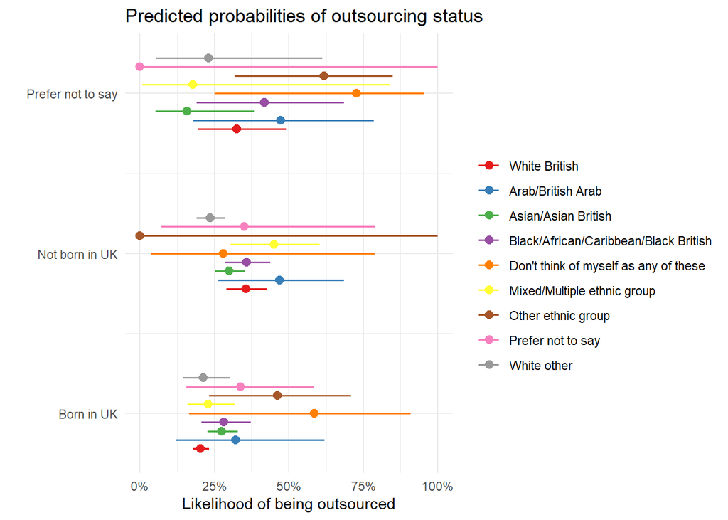

```r
sjPlot::plot_model(mod, type = "pred", legend.title="", terms = c("BORNUK_binary","Ethnicity_collapsed"), dodge=0.5) +#

  coord_flip() +
  xlab("") + ylab("Likelihood of being outsourced") +
  theme_minimal()
```

```r
ems <- emmeans(mod, specs = "BORNUK_binary", by = "Ethnicity_collapsed")
cons <- summary(contrast(ems, "pairwise",adjust="tukey"))
sig_cons <- cons %>% filter(p.value < .05) %>%
  mutate(
    or = 1 / exp(estimate), .after=estimate # 1 / or because we want to express comparison - white(ref) (contrast expresses white(ref) - comparison)
  )
```

The plot below visualises these effects.

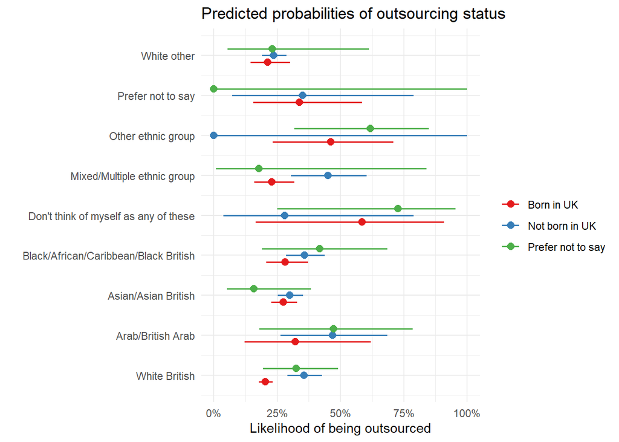

```r
sjPlot::plot_model(mod, type = "pred", legend.title="", terms = c("Ethnicity_collapsed","BORNUK_binary"), dodge=0.5) +#

  coord_flip() +
  xlab("") + ylab("Likelihood of being outsourced") +
  theme_minimal()
```

```r
mod <- glm(outsourcing_status ~ BORNUK_binary * Ethnicity_collapsed_disaggregated + Age + Gender + Has_Degree + Region, data, weights = NatRepemployees, family="quasibinomial")
summary(mod)

tjur <- data %>%
  filter(!is.na(Ethnicity_collapsed_disaggregated)) %>%
  mutate(pred = predict(mod, type = "response")) %>%
  group_by(outsourcing_status) %>%
  summarise(weighted_mean = weighted.mean(pred, NatRepemployees)) %>%
  summarise(tjur_r2 = diff(weighted_mean)) %>%
  pull()

coefs <- extract_glm_coefs(mod, only_sig=T)
coefs_all <- extract_glm_coefs(mod)
```

For model 2, the value of Tjur’s pseudo *R<sup>2</sup>* is 0.046. The table below shows the model coefficients.

```r
labels <- c(
  'Intercept',
  'Migration: Not born in the UK',
  "Ethnicity: Irish",
  "Ethnicity: Gypsy or Irish Traveller",
  "Ethnicity: Roma",
  "Ethnicity: Any other White background",
  "Ethnicity: White and Black Caribbean",
  "Ethnicity: White and Black African",
  "Ethnicity: White and Asian",
  "Ethnicity: Any other Mixed/Multiple ethnic background",
  "Ethnicity: Indian",
  "Ethnicity: Pakistani",
  "Ethnicity: Bangladeshi",
  "Ethnicity: Chinese",
  "Ethnicity: Any other Asian background",
  "Ethnicity: African",
  "Ethnicity: Caribbean",
  "Ethnicity: Any other Black, Black British, or Caribbean background",
  "Ethnicity: Arab",
  "Ethnicity: Any other ethnic group",
  "Ethnicity: Don't think of myself as any of these",
  "Ethnicity: Prefer not to say",
  'Age',
  'Gender: Male',
  'Gender: Other',
  'Gender: Prefer not to say',
  'Education: Has degree',
  "Education: Don't know",
  'Region: East Midlands',
  'Region: East of England',
  'Region: North East',
  'Region: North West',
  'Region: Northern Ireland',
  'Region: Scotland',
  'Region: South East',
  'Region: South West',
  'Region: Wales',
  'Region: West Midlands',
  'Region: Yorkshire and the Humber',
  "Interaction: Not born in UK x Irish",
  "Interaction: Not born in UK x Gypsy or Irish Traveller",
  # "Interaction: Not born in UK x Roma",
  "Interaction: Not born in UK x Any other White background",
  "Interaction: Not born in UK x White and Black Caribbean",
  "Interaction: Not born in UK x White and Black African",
  "Interaction: Not born in UK x White and Asian",
  "Interaction: Not born in UK x Any other Mixed/Multiple ethnic background",
  "Interaction: Not born in UK x Indian",
  "Interaction: Not born in UK x Pakistani",
  "Interaction: Not born in UK x Bangladeshi",
  "Interaction: Not born in UK x Chinese",
  "Interaction: Not born in UK x Any other Asian background",
  "Interaction: Not born in UK x African",
  "Interaction: Not born in UK x Caribbean",
  "Interaction: Not born in UK x Any other Black, Black British, or Caribbean background",
  "Interaction: Not born in UK x Arab",
  "Interaction: Not born in UK x Any other ethnic group",
  "Interaction: Not born in UK x Don't think of myself as any of these",
  "Interaction: Not born in UK x Prefer not to say"


)

tab_model(mod,
          pred.labels = labels,
          dv.labels = "Outsourcing",
          show.r2 = FALSE)
```

|  | Outsourcing |  |  |
| --- | --- | --- | --- |
| Predictors | Odds Ratios | CI | p |
| (Intercept) | 0.63 | 0.49 – 0.80 | **<0.001** |
| BORNUK_binaryNot born in UK | 2.15 | 1.61 – 2.85 | **<0.001** |
| BORNUK_binaryPrefer not to say | 1.89 | 0.92 – 3.64 | 0.068 |
| Ethnicity_collapsed_disaggregatedIrish | 0.93 | 0.46 – 1.73 | 0.825 |
| Ethnicity_collapsed_disaggregatedGypsy or Irish Traveller | 1.67 | 0.29 – 6.97 | 0.506 |
| Ethnicity_collapsed_disaggregatedRoma | 0.81 | 0.13 – 3.65 | 0.794 |
| Ethnicity_collapsed_disaggregatedAny other White background | 1.11 | 0.53 – 2.13 | 0.762 |
| Ethnicity_collapsed_disaggregatedWhite and Black Caribbean | 0.53 | 0.19 – 1.19 | 0.164 |
| Ethnicity_collapsed_disaggregatedWhite and Black African | 3.38 | 1.26 – 8.74 | **0.012** |
| Ethnicity_collapsed_disaggregatedWhite and Asian | 0.90 | 0.31 – 2.12 | 0.826 |
| Ethnicity_collapsed_disaggregatedAny other Mixed / Multiple ethnic background | 1.87 | 0.77 – 4.12 | 0.137 |
| Ethnicity_collapsed_disaggregatedIndian | 1.32 | 0.90 – 1.90 | 0.146 |
| Ethnicity_collapsed_disaggregatedPakistani | 2.67 | 1.73 – 4.08 | **<0.001** |
| Ethnicity_collapsed_disaggregatedBangladeshi | 1.81 | 0.90 – 3.48 | 0.085 |
| Ethnicity_collapsed_disaggregatedChinese | 0.53 | 0.20 – 1.16 | 0.149 |
| Ethnicity_collapsed_disaggregatedAny other Asian background | 1.06 | 0.44 – 2.27 | 0.888 |
| Ethnicity_collapsed_disaggregatedAfrican | 1.52 | 0.77 – 2.83 | 0.206 |
| Ethnicity_collapsed_disaggregatedCaribbean | 1.12 | 0.53 – 2.16 | 0.752 |
| Ethnicity_collapsed_disaggregatedAny other Black, Black British, or Caribbean background | 2.60 | 1.09 – 5.87 | **0.024** |
| Ethnicity_collapsed_disaggregatedArab | 1.85 | 0.47 – 6.02 | 0.328 |
| Ethnicity_collapsed_disaggregatedAny other ethnic group | 3.34 | 1.14 – 9.68 | **0.024** |
| Ethnicity_collapsed_disaggregatedDon’t think of myself as any of these | 5.43 | 0.63 – 41.49 | 0.089 |
| Ethnicity_collapsed_disaggregatedPrefer not to say | 1.99 | 0.65 – 5.18 | 0.183 |
| Age | 0.98 | 0.98 – 0.98 | **<0.001** |
| GenderFemale | 0.69 | 0.62 – 0.78 | **<0.001** |
| GenderOther | 0.87 | 0.18 – 2.94 | 0.844 |
| GenderPrefer not to say | 0.77 | 0.23 – 2.02 | 0.630 |
| Has_DegreeNo | 1.06 | 0.94 – 1.18 | 0.352 |
| Has_DegreeDon't know | 1.21 | 0.78 – 1.84 | 0.379 |
| RegionEast Midlands | 0.94 | 0.75 – 1.19 | 0.633 |
| RegionEast of England | 0.59 | 0.46 – 0.75 | **<0.001** |
| RegionNorth East | 0.63 | 0.45 – 0.87 | **0.007** |
| RegionNorth West | 0.84 | 0.67 – 1.04 | 0.111 |
| RegionNorthern Ireland | 0.71 | 0.47 – 1.04 | 0.090 |
| RegionScotland | 0.69 | 0.54 – 0.87 | **0.002** |
| RegionSouth East | 0.62 | 0.50 – 0.76 | **<0.001** |
| RegionSouth West | 0.68 | 0.53 – 0.86 | **0.002** |
| RegionWales | 0.90 | 0.68 – 1.19 | 0.472 |
| RegionWest Midlands | 0.80 | 0.64 – 1.00 | 0.051 |
| RegionYorkshire and the Humber | 0.67 | 0.52 – 0.85 | **0.001** |
| BORNUK_binaryNot born in UK:Ethnicity_collapsed_disaggregatedIrish | 0.28 | 0.04 – 1.19 | 0.118 |
| BORNUK_binaryPrefer not to say:Ethnicity_collapsed_disaggregatedIrish | 1.31 | 0.04 – 14.51 | 0.843 |
| BORNUK_binaryNot born in UK:Ethnicity_collapsed_disaggregatedGypsy or Irish Traveller | 0.00 | NA – 22590905615836190406828240264448.00 | 0.981 |
| BORNUK_binaryNot born in UK:Ethnicity_collapsed_disaggregatedAny other White background | 0.52 | 0.24 – 1.18 | 0.099 |
| BORNUK_binaryPrefer not to say:Ethnicity_collapsed_disaggregatedAny other White background | 0.38 | 0.02 – 3.14 | 0.425 |
| BORNUK_binaryNot born in UK:Ethnicity_collapsed_disaggregatedWhite and Black Caribbean | 0.00 | NA – 2447279996931572378468028602826606284446828640680002.00 | 0.985 |
| BORNUK_binaryPrefer not to say:Ethnicity_collapsed_disaggregatedWhite and Black Caribbean | 0.00 | NA – 4090449279912267828480800222804264028286068040.00 | 0.985 |
| BORNUK_binaryNot born in UK:Ethnicity_collapsed_disaggregatedWhite and Black African | 0.46 | 0.11 – 1.91 | 0.283 |
| BORNUK_binaryPrefer not to say:Ethnicity_collapsed_disaggregatedWhite and Black African | 0.00 | NA – 27758150292894820574424046844826686626666000660648262664400648242208406404488482.00 | 0.987 |
| BORNUK_binaryNot born in UK:Ethnicity_collapsed_disaggregatedWhite and Asian | 2.76 | 0.46 – 18.15 | 0.268 |
| BORNUK_binaryNot born in UK:Ethnicity_collapsed_disaggregatedAny other Mixed / Multiple ethnic background | 0.69 | 0.19 – 2.52 | 0.571 |
| BORNUK_binaryPrefer not to say:Ethnicity_collapsed_disaggregatedAny other Mixed / Multiple ethnic background | 1.10 | 0.00 – 100.78 | 0.964 |
| BORNUK_binaryNot born in UK:Ethnicity_collapsed_disaggregatedIndian | 0.55 | 0.30 – 1.02 | 0.056 |
| BORNUK_binaryPrefer not to say:Ethnicity_collapsed_disaggregatedIndian | 0.38 | 0.02 – 2.77 | 0.393 |
| BORNUK_binaryNot born in UK:Ethnicity_collapsed_disaggregatedPakistani | 0.43 | 0.20 – 0.91 | **0.029** |
| BORNUK_binaryPrefer not to say:Ethnicity_collapsed_disaggregatedPakistani | 0.00 | NA – 1290359365779453784184008226404264648460062422664604048260242.00 | 0.985 |
| BORNUK_binaryNot born in UK:Ethnicity_collapsed_disaggregatedBangladeshi | 0.38 | 0.12 – 1.13 | 0.087 |
| BORNUK_binaryPrefer not to say:Ethnicity_collapsed_disaggregatedBangladeshi | 0.30 | 0.04 – 1.72 | 0.196 |
| BORNUK_binaryNot born in UK:Ethnicity_collapsed_disaggregatedChinese | 0.88 | 0.32 – 2.71 | 0.815 |
| BORNUK_binaryNot born in UK:Ethnicity_collapsed_disaggregatedAny other Asian background | 0.90 | 0.36 – 2.43 | 0.821 |
| BORNUK_binaryPrefer not to say:Ethnicity_collapsed_disaggregatedAny other Asian background | 0.00 | NA – 5338259679382987604048.00 | 0.979 |
| BORNUK_binaryNot born in UK:Ethnicity_collapsed_disaggregatedAfrican | 0.69 | 0.32 – 1.52 | 0.340 |
| BORNUK_binaryPrefer not to say:Ethnicity_collapsed_disaggregatedAfrican | 0.89 | 0.17 – 4.34 | 0.889 |
| BORNUK_binaryNot born in UK:Ethnicity_collapsed_disaggregatedCaribbean | 0.84 | 0.19 – 3.31 | 0.808 |
| BORNUK_binaryPrefer not to say:Ethnicity_collapsed_disaggregatedCaribbean | 8524427.63 | 0.00 – NA | 0.984 |
| BORNUK_binaryNot born in UK:Ethnicity_collapsed_disaggregatedAny other Black, Black British, or Caribbean background | 0.25 | 0.04 – 1.29 | 0.116 |
| BORNUK_binaryPrefer not to say:Ethnicity_collapsed_disaggregatedAny other Black, Black British, or Caribbean background | 0.00 | NA – 108569179734494043218888088604.00 | 0.979 |
| BORNUK_binaryNot born in UK:Ethnicity_collapsed_disaggregatedArab | 0.86 | 0.19 – 4.38 | 0.849 |
| BORNUK_binaryNot born in UK:Ethnicity_collapsed_disaggregatedAny other ethnic group | 0.00 | NA – 1170.78 | 0.951 |
| BORNUK_binaryNot born in UK:Ethnicity_collapsed_disaggregatedDon’t think of myself as any of these | 0.13 | 0.00 – 2.41 | 0.181 |
| BORNUK_binaryNot born in UK:Ethnicity_collapsed_disaggregatedPrefer not to say | 0.49 | 0.04 – 4.29 | 0.528 |
| BORNUK_binaryPrefer not to say:Ethnicity_collapsed_disaggregatedPrefer not to say | 0.00 | NA – 4938303027178973.00 | 0.976 |
| Observations | 9812 |  |  |

```r
ems <- emmeans(mod, specs = "Ethnicity_collapsed_disaggregated", by = "BORNUK_binary")
cons <- summary(contrast(ems, "pairwise",adjust="tukey"))
sig_cons <- cons %>% filter(p.value < .05) %>%
  mutate(
    or = 1 / exp(estimate), .after=estimate # 1 / or because we want to express comparison - white(ref) (contrast expresses white(ref) - comparison)
  )
```

Again for this model we calculated estimated marginal means of the ethnicity x migration effect. Examining the effect of ethnicity within each level of migration, we find that:

1. Among people born in the UK, Pakistani workers are 2.67 times more likely to be outsourced than English/Welsh/Scottish/Northern Irish/British workers.

No other differences were significant. The plot below visualises these effects.

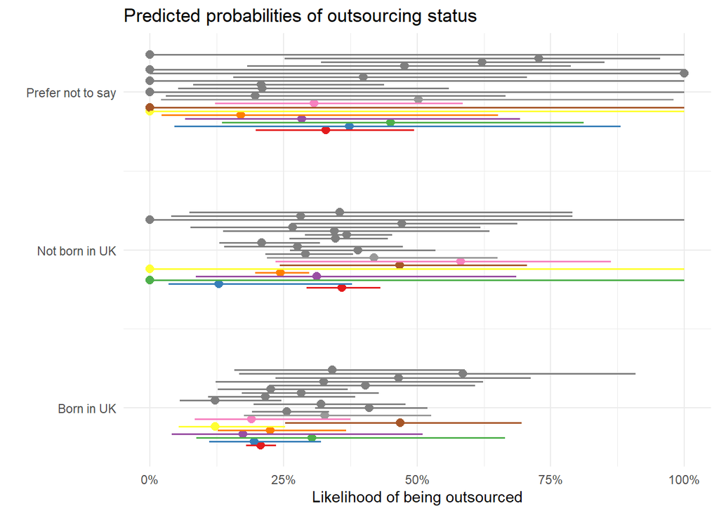

```r
sjPlot::plot_model(mod, type = "pred", legend.title="", terms = c("BORNUK_binary","Ethnicity_collapsed_disaggregated"), dodge=0.5) +#

  coord_flip() +
  xlab("") + ylab("Likelihood of being outsourced") +
  theme_minimal() +
  theme(
    legend.position = "none"
  )
```

```r
ems <- emmeans(mod, specs = "BORNUK_binary", by = "Ethnicity_collapsed_disaggregated")
cons <- summary(contrast(ems, "pairwise",adjust="tukey"))
sig_cons <- cons %>% filter(p.value < .05) %>%
  mutate(
    or = 1 / exp(estimate), .after=estimate # 1 / or because we want to express comparison - white(ref) (contrast expresses white(ref) - comparison)
  )
```

Examining the effect of migration for particular ethnicities, we find that:

1. Among English/Welsh/Scottish/Northern Irish/British workers, people not born in the UK are 2.15 more likely to be outsourced than people born in the UK
2. Among Mixed White and Asian workers, people not born in the UK are 5.93 more likely to be outsourced than people born in the UK (**NB n < 50 for this group**).

No other differences were significant. The plot below visualises these findings.

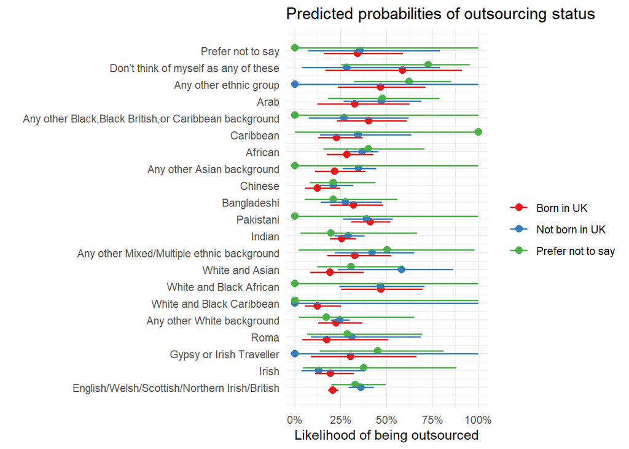

```r
sjPlot::plot_model(mod, type = "pred", legend.title="", terms = c("Ethnicity_collapsed_disaggregated","BORNUK_binary"), dodge=0.5) +#

  coord_flip() +
  xlab("") + ylab("Likelihood of being outsourced") +
  theme_minimal()
```

# 5 Outsourced workers are more likely to be men, but women are more likely to be low-paid outsourced workers

```r
mod <- glm(outsourcing_status ~ BORNUK_binary + Ethnicity_collapsed_disaggregated + Age + Gender + Has_Degree + Region, data, weights = NatRepemployees, family="quasibinomial")
summary(mod)

coefs <- extract_glm_coefs(mod, only_sig=T)

gender_coefs <- coefs %>%
  filter(variable == "GenderMale")
```

```r
# Annual income
# Intercept only
mod_base <- lm(income_annual_all ~ 1, income_data2, weights = NatRepemployees)
# H1
mod_annual <- lm(income_annual_all ~ Age + Gender + Has_Degree + Ethnicity_collapsed + Region + outsourcing_status + BORNUK_labelled, income_data2, weights = NatRepemployees)

summary(mod_annual)

# F and p
f_annual <- round(anova(mod_base, mod_annual)[2,"F"],2)
p_annual <- anova(mod_base, mod_annual)[2,"Pr(>F)"]
if(p_annual < .001){
  p_annual = "< .001"
} else{
  p_annual = paste0("= ",round(p_annual,3))
}

# Degrees of freedom
dfs_annual <- as.list(anova(mod_base, mod_annual)[2,c("Df","Res.Df")])
# R2
rsquare_annual <- round(summary(mod_annual)$r.squared,2)

# Weekly income
# Intercept only
mod_base <- lm(income_weekly_all ~ 1, income_data2, weights = NatRepemployees)
# H1
mod_weekly <- lm(income_weekly_all ~ Age + Gender + Has_Degree + Ethnicity_collapsed + Region + outsourcing_status + BORNUK_labelled, income_data2, weights = NatRepemployees)
summary(mod_weekly)

# F and p
f_weekly <- round(anova(mod_base, mod_weekly)[2,"F"],2)
p_weekly <- anova(mod_base, mod_weekly)[2,"Pr(>F)"]
if(p_weekly < .001){
  p_weekly = "< .001"
} else{
  p_weekly = paste0("= ",round(p_weekly,3))
}

# Degrees of freedom
dfs_weekly <- as.list(anova(mod_base, mod_weekly)[2,c("Df","Res.Df")])
# R2
rsquare_weekly <- round(summary(mod_weekly)$r.squared,2)
```

```r
annual_gender_coef <- extract_lm_coefs(mod_annual, only_sig = T) %>%
  filter(variable == "GenderMale")

weekly_gender_coef <- extract_lm_coefs(mod_weekly, only_sig = T) %>%
  filter(variable == "GenderMale")
```

We next explored whether outsourcing compounds this gender pay gap by adding an outsourcing:gender interaction term into the previous models.

```r
# Annual income

# H1
mod_annual_int <- lm(income_annual_all ~ Age + Gender + Has_Degree + Ethnicity_collapsed + Region + outsourcing_status + BORNUK_labelled + Gender:outsourcing_status, income_data, weights = NatRepemployees)

summary(mod_annual_int)

# F and p
anova_test <- anova(mod_annual, mod_annual_int)
f_annual <- anova_test[2,"F"] %>% round(2)
p_annual <- anova_test[2,"Pr(>F)"]
if(p_annual < .001){
  p_annual = "< .001"
} else{
  p_annual = paste0("= ",round(p_annual,3))
}

# Degrees of freedom
dfs_annual <- as.list(anova_test[2,c("Df","Res.Df")])
# R2
rsquare_annual <- round(summary(mod_annual_int)$r.squared,2)

# Weekly income

# H1
mod_weekly_int <- lm(income_weekly_all ~ Age + Gender + Has_Degree + Ethnicity_collapsed + Region + outsourcing_status + BORNUK_labelled + Gender:outsourcing_status, income_data, weights = NatRepemployees)
summary(mod_weekly_int)

# F and p
anova_test <- anova(mod_weekly, mod_weekly_int)

f_weekly <-  anova_test[2,"F"] %>% round(2)
p_weekly <- anova_test[2,"Pr(>F)"]
if(p_weekly < .001){
  p_weekly = "< .001"
} else{
  p_weekly = paste0("= ", round(p_weekly,3))
}

# Degrees of freedom
dfs_weekly <- as.list(anova_test[2,c("Df","Res.Df")])
# R2
rsquare_weekly <- round(summary(mod_weekly_int)$r.squared,2)
```

For both models, adding the interaction effect did not improve model fit (*R<sup>2</sup>* = 0.18, *F*(3, 8068) = 0.74, *p* = 0.531). The tables below show the coefficients for each model.

```r
labels <- c(
  'Intercept',
  'Age',
  'Gender: Male',
  'Gender: Other',
  'Gender: Prefer not to say',
  'Education: Has degree',
  "Education: Don't know",
  'Ethnicity: Arab/British Arab',
  'Ethnicity: Asian/Asian British',
  'Ethnicity: Black/African/Caribbean/Black British',
  'Ethnicity: Mixed/Multiple ethnic group',
  'Ethnicity: Other ethnic group',
  'Ethnicity: Prefer not to say',
  'Ethnicity: White other',
  'Region: East Midlands',
  'Region: East of England',
  'Region: North East',
  'Region: North West',
  'Region: Northern Ireland',
  'Region: Scotland',
  'Region: South East',
  'Region: South West',
  'Region: Wales',
  'Region: West Midlands',
  'Region: Yorkshire and the Humber',
  'Outsourcing: Outsourced',
  'Migration: Arrived within the last year',
  'Migration: Arrived within the last 3 years',
  'Migration: Arrived within the last 5 years',
  'Migration: Arrived within the last 10 years',
  'Migration: Arrived within the last 15 years',
  'Migration: Arrived within the last 20 years',
  'Migration: Arrived within the last 30 years',
  'Migration: Arrived more than 30 years ago',
  'Migration: Prefer not to say',
  'Interaction: Outsourcing x Gender Male',
  'Interaction: Outsourcing x Gender Other',
  'Interaction: Outsourcing x Gender Prefer not to say'
)

tab_model(mod_annual_int, pred.labels = labels, dv.labels = "Annual income")
```

Table 4: Linear regression predicting annual income with outsourcing:gender interaction term

|  | Annual income |  |  |
| --- | --- | --- | --- |
| Predictors | Estimates | CI | p |
| (Intercept) | 39092.47 | 37809.50 – 40375.44 | **<0.001** |
| Age | 14.30 | -6.51 – 35.10 | 0.178 |
| GenderFemale | -7004.18 | -7586.05 – -6422.30 | **<0.001** |
| GenderOther | -3445.67 | -10995.26 – 4103.92 | 0.371 |
| GenderPrefer not to say | -2634.20 | -9886.89 – 4618.49 | 0.477 |
| Has_DegreeNo | -8169.16 | -8722.09 – -7616.22 | **<0.001** |
| Has_DegreeDon't know | -9849.18 | -12104.91 – -7593.45 | **<0.001** |
| Ethnicity_collapsedArab/British Arab | -170.96 | -4867.74 – 4525.81 | 0.943 |
| Ethnicity_collapsedAsian/Asian British | -472.69 | -1574.78 – 629.39 | 0.401 |
| Ethnicity_collapsedBlack/African/Caribbean/Black British | -1203.91 | -2816.96 – 409.13 | 0.143 |
| Ethnicity_collapsedDon't think of myself as any of these | -3193.67 | -12753.23 – 6365.88 | 0.513 |
| Ethnicity_collapsedMixed/Multiple ethnic group | -1511.45 | -3492.47 – 469.58 | 0.135 |
| Ethnicity_collapsedOther ethnic group | 3593.79 | -1002.26 – 8189.84 | 0.125 |
| Ethnicity_collapsedPrefer not to say | -81.55 | -5288.77 – 5125.67 | 0.976 |
| Ethnicity_collapsedWhite other | -601.41 | -1984.70 – 781.89 | 0.394 |
| RegionEast Midlands | -5879.63 | -7110.82 – -4648.44 | **<0.001** |
| RegionEast of England | -4135.62 | -5295.46 – -2975.79 | **<0.001** |
| RegionNorth East | -4865.76 | -6404.23 – -3327.29 | **<0.001** |
| RegionNorth West | -4502.26 | -5628.38 – -3376.14 | **<0.001** |
| RegionNorthern Ireland | -6358.52 | -8158.35 – -4558.69 | **<0.001** |
| RegionScotland | -5476.68 | -6678.10 – -4275.26 | **<0.001** |
| RegionSouth East | -3488.28 | -4540.37 – -2436.18 | **<0.001** |
| RegionSouth West | -5772.53 | -6971.45 – -4573.60 | **<0.001** |
| RegionWales | -5238.94 | -6705.78 – -3772.10 | **<0.001** |
| RegionWest Midlands | -4783.07 | -5956.82 – -3609.31 | **<0.001** |
| RegionYorkshire and the Humber | -5477.80 | -6676.53 – -4279.07 | **<0.001** |
| outsourcing_statusOutsourced | -2979.46 | -3945.17 – -2013.76 | **<0.001** |
| BORNUK_labelledWithin the last year | -6043.23 | -8320.40 – -3766.06 | **<0.001** |
| BORNUK_labelledWithin the last 3 years | -2386.09 | -4418.13 – -354.05 | **0.021** |
| BORNUK_labelledWithin the last 5 years | -1849.05 | -4152.16 – 454.06 | 0.116 |
| BORNUK_labelledWithin the last 10 years | -719.66 | -2514.13 – 1074.81 | 0.432 |
| BORNUK_labelledWithin the last 15 years | 718.31 | -1297.19 – 2733.81 | 0.485 |
| BORNUK_labelledWithin the last 20 years | 1602.21 | -532.38 – 3736.80 | 0.141 |
| BORNUK_labelledWithin the last 30 years | 2893.95 | 382.76 – 5405.14 | **0.024** |
| BORNUK_labelledMore than 30 years ago | -58.23 | -2016.55 – 1900.09 | 0.954 |
| BORNUK_labelledPrefer not to say | -1683.14 | -5300.38 – 1934.09 | 0.362 |
| GenderFemale:outsourcing_statusOutsourced | 18.18 | -1412.01 – 1448.37 | 0.980 |
| GenderOther:outsourcing_statusOutsourced | -12395.16 | -28915.23 – 4124.91 | 0.141 |
| GenderPrefer not to say:outsourcing_statusOutsourced | -2506.28 | -28505.03 – 23492.47 | 0.850 |
| Observations | 8107 |  |  |
| R<sup>2</sup> / R<sup>2</sup> adjusted | 0.182 / 0.178 |  |  |

```r
tab_model(mod_weekly_int, pred.labels = labels, dv.labels = "Weekly income")
```

Table 5: Linear regression predicting weekly income with outsourcing:gender interaction term

|  | Weekly income |  |  |
| --- | --- | --- | --- |
| Predictors | Estimates | CI | p |
| (Intercept) | 839.92 | 812.36 – 867.49 | **<0.001** |
| Age | 0.31 | -0.14 – 0.75 | 0.178 |
| GenderFemale | -150.49 | -162.99 – -137.99 | **<0.001** |
| GenderOther | -74.03 | -236.24 – 88.18 | 0.371 |
| GenderPrefer not to say | -56.60 | -212.43 – 99.23 | 0.477 |
| Has_DegreeNo | -175.52 | -187.40 – -163.64 | **<0.001** |
| Has_DegreeDon't know | -211.62 | -260.08 – -163.15 | **<0.001** |
| Ethnicity_collapsedArab/British Arab | -3.67 | -104.59 – 97.24 | 0.943 |
| Ethnicity_collapsedAsian/Asian British | -10.16 | -33.84 – 13.52 | 0.401 |
| Ethnicity_collapsedBlack/African/Caribbean/Black British | -25.87 | -60.52 – 8.79 | 0.143 |
| Ethnicity_collapsedDon't think of myself as any of these | -68.62 | -274.01 – 136.77 | 0.513 |
| Ethnicity_collapsedMixed/Multiple ethnic group | -32.47 | -75.04 – 10.09 | 0.135 |
| Ethnicity_collapsedOther ethnic group | 77.21 | -21.53 – 175.96 | 0.125 |
| Ethnicity_collapsedPrefer not to say | -1.75 | -113.63 – 110.13 | 0.976 |
| Ethnicity_collapsedWhite other | -12.92 | -42.64 – 16.80 | 0.394 |
| RegionEast Midlands | -126.33 | -152.78 – -99.87 | **<0.001** |
| RegionEast of England | -88.86 | -113.78 – -63.94 | **<0.001** |
| RegionNorth East | -104.54 | -137.60 – -71.49 | **<0.001** |
| RegionNorth West | -96.73 | -120.93 – -72.54 | **<0.001** |
| RegionNorthern Ireland | -136.62 | -175.29 – -97.95 | **<0.001** |
| RegionScotland | -117.67 | -143.48 – -91.86 | **<0.001** |
| RegionSouth East | -74.95 | -97.55 – -52.34 | **<0.001** |
| RegionSouth West | -124.03 | -149.79 – -98.27 | **<0.001** |
| RegionWales | -112.56 | -144.08 – -81.05 | **<0.001** |
| RegionWest Midlands | -102.77 | -127.99 – -77.55 | **<0.001** |
| RegionYorkshire and the Humber | -117.69 | -143.45 – -91.94 | **<0.001** |
| outsourcing_statusOutsourced | -64.02 | -84.76 – -43.27 | **<0.001** |
| BORNUK_labelledWithin the last year | -129.84 | -178.77 – -80.92 | **<0.001** |
| BORNUK_labelledWithin the last 3 years | -51.27 | -94.93 – -7.61 | **0.021** |
| BORNUK_labelledWithin the last 5 years | -39.73 | -89.21 – 9.76 | 0.116 |
| BORNUK_labelledWithin the last 10 years | -15.46 | -54.02 – 23.09 | 0.432 |
| BORNUK_labelledWithin the last 15 years | 15.43 | -27.87 – 58.74 | 0.485 |
| BORNUK_labelledWithin the last 20 years | 34.42 | -11.44 – 80.29 | 0.141 |
| BORNUK_labelledWithin the last 30 years | 62.18 | 8.22 – 116.13 | **0.024** |
| BORNUK_labelledMore than 30 years ago | -1.25 | -43.33 – 40.82 | 0.954 |
| BORNUK_labelledPrefer not to say | -36.16 | -113.88 – 41.56 | 0.362 |
| GenderFemale:outsourcing_statusOutsourced | 0.39 | -30.34 – 31.12 | 0.980 |
| GenderOther:outsourcing_statusOutsourced | -266.32 | -621.26 – 88.63 | 0.141 |
| GenderPrefer not to say:outsourcing_statusOutsourced | -53.85 | -612.45 – 504.75 | 0.850 |
| Observations | 8107 |  |  |
| R<sup>2</sup> / R<sup>2</sup> adjusted | 0.182 / 0.178 |  |  |

```r
ems <- emmeans(mod_annual_int, specs = "Gender", by = "outsourcing_status", nuisance = "BORNUK_labelled")
cons <- summary(contrast(ems, "pairwise",adjust="tukey"))
sig_cons <- cons %>% filter(p.value < .05)
```

```r
ems <- emmeans(mod_annual_int, specs = "outsourcing_status", by = "Gender", nuisance = "BORNUK_labelled")
cons <- summary(contrast(ems, "pairwise",adjust="tukey"))
sig_cons2 <- cons %>% filter(p.value < .05)
```

The interaction term is non-significant. Estimated marginal means show that:

- Among not outsourced workers, men are paid £7004.18 more than women
- Among outsourced workers, men are paid £6986 more than women
- Among men, not outsourced workers are paid £2979.46 more than outsourced workers.
- Among women, not outsourced workers are paid £2961.28 more than outsourced workers.

The plot below illustrates the main effects that men are paid more than women and that outsourced men and women are paid less than non-outsourced men and women. The lack of interaction indicates that the difference in pay between men and women does not significantly differ between outsourced and non-outsourced people.

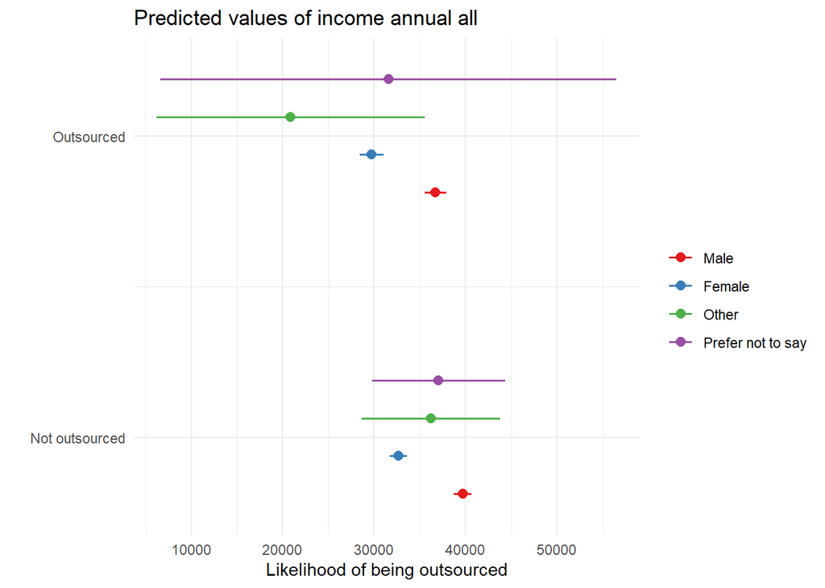

```r
sjPlot::plot_model(mod_annual_int, type = "pred", legend.title="", terms = c("outsourcing_status","Gender"), dodge=0.5) +#

  coord_flip() +
  xlab("") + ylab("Likelihood of being outsourced") +
  theme_minimal()
```

# 6 Age

```r
mod <- glm(outsourcing_status ~ BORNUK_binary + Ethnicity_collapsed_disaggregated + Age + Gender + Has_Degree + Region, data, weights = NatRepemployees, family="quasibinomial")
summary(mod)

coefs <- extract_glm_coefs(mod, only_sig=T)

age_coefs <- coefs %>%
  filter(variable == "Age")
```

We found that age was a significant predictor of the likelihood of being outsourced. The model indicates that for each year older a worker is, they are 0.98 times as likely (i.e. 2% less likely) to be outsourced.